# Discriminating evolution of acute myeloid leukaemia from age-related clonal haematopoiesis

Grace Collord & Moritz Gerstung

Tue Jul 24 16:38:48 2018

# 1 Preliminaries

## 1.1 Libraries

```r
library(CoxHD)
library(survAUC)
library(survivalROC)
library(glmnet)
library(RColorBrewer)
library(stringr)
library(dplyr)
library(readr)

set1 <- RColorBrewer::brewer.pal(8, "Set1")
```

Helper functions

```r
superSet <- function(x, s, fill=NA){
    i <- intersect(colnames(x), s)
    n <- setdiff(s, colnames(x))
    y <- x[,i]
    if(length(n) > 0)
        y <- cbind(y,  matrix(fill, ncol=length(n), dimnames=list(NULL, n)) )[,s]
    return(y)
}
```

# 2 AML incidence data

Use known AML incidence to correct bias using weighted controls. The expected incidence of AML was calculated from the UK office of national statistics, available at http://www.cancerresearchuk.org/health-professional/cancer-statistics/statistics-by-cancer-type/leukaemia-aml/incidence. Spline function to interpolate Male denoted by 1 and female by 0

```r
age_incidence <- read.table("data/aml_age_incidence.txt", header=TRUE, sep="\t")
head(age_incidence)
```

|  | Age.Range | Male.Cases | Female.Cases | Male.Rates | Female.Rates |
| --- | --- | --- | --- | --- | --- |
| 1 | 0 to 04 | 18 | 12 | 0.9 | 0.6 |
| 2 | 05 to 09 | 10 | 10 | 0.5 | 0.5 |
| 3 | 10 to 14 | 8 | 10 | 0.4 | 0.6 |
| 4 | 15 to 19 | 15 | 14 | 0.7 | 0.8 |
| 5 | 20 to 24 | 21 | 18 | 1.0 | 0.8 |
| 6 | 25 to 29 | 22 | 20 | 1.0 | 0.9 |

```r
tail(age_incidence)
```

|  | Age.Range | Male.Cases | Female.Cases | Male.Rates | Female.Rates |
| --- | --- | --- | --- | --- | --- |
| 14 | 65 to 69 | 205 | 140 | 12.2 | 7.9 |
| 15 | 70 to 74 | 256 | 162 | 21.2 | 12.0 |
| 16 | 75 to 79 | 270 | 179 | 28.3 | 15.7 |
| 17 | 80 to 84 | 235 | 165 | 36.1 | 18.4 |
| 18 | 85 to 89 | 139 | 122 | 40.4 | 20.7 |
| 19 | 90+ | 53 | 85 | 35.6 | 22.2 |

```r
str(age_incidence)
```

```
## 'data.frame':    19 obs. of  5 variables:
##  $ Age.Range   : Factor w/ 19 levels "0 to 04","05 to 09",..: 1 2 3 4 5 6 7 8 9 10 ...
##  $ Male.Cases  : int  18 10 8 15 21 22 21 34 39 51 ...
##  $ Female.Cases: int  12 10 10 14 18 20 20 23 39 53 ...
##  $ Male.Rates  : num  0.9 0.5 0.4 0.7 1 1 1 1.7 1.8 2.2 ...
##  $ Female.Rates: num  0.6 0.5 0.6 0.8 0.8 0.9 0.9 1.2 1.7 2.2 ...
```

```r
aml_inc <- function(gender, x){
    if(gender==1)
        splinefun(x=c(seq(0,90,5)), y=c(cumsum(age_incidence$Male.Rates/100000)*5), method="mono")(x)
    else
        splinefun(x=c(seq(0,90,5)), y=c(cumsum(age_incidence$Female.Rates/100000)*5), method="mono")(x)
}
```

All cause mortality from the office of national statistics (https://www.ons.gov.uk/).

```r
all_cause_mortality <- read.table("data/all_cause_mortality.txt", sep="\t", skip=1, header=TRUE)
head(all_cause_mortality)
```

|  | x | mx | qx | lx | dx | ex | X | mx.1 | qx.1 | lx.1 | dx.1 | ex.1 |
| --- | --- | --- | --- | --- | --- | --- | --- | --- | --- | --- | --- | --- |
| 1 | 0 | 0.004234 | 0.004225 | 100000.0 | 422.5 | 79.17 | NA | 0.003521 | 0.003515 | 100000.0 | 351.5 | 82.86 |
| 2 | 1 | 0.000306 | 0.000306 | 99577.5 | 30.5 | 78.51 | NA | 0.000246 | 0.000246 | 99648.5 | 24.5 | 82.15 |
| 3 | 2 | 0.000163 | 0.000163 | 99547.1 | 16.2 | 77.53 | NA | 0.000137 | 0.000137 | 99624.0 | 13.6 | 81.17 |
| 4 | 3 | 0.000127 | 0.000127 | 99530.8 | 12.6 | 76.54 | NA | 0.000105 | 0.000105 | 99610.4 | 10.4 | 80.18 |
| 5 | 4 | 0.000090 | 0.000090 | 99518.2 | 8.9 | 75.55 | NA | 0.000081 | 0.000081 | 99599.9 | 8.1 | 79.19 |
| 6 | 5 | 0.000092 | 0.000092 | 99509.3 | 9.2 | 74.56 | NA | 0.000067 | 0.000067 | 99591.8 | 6.7 | 78.20 |

```r
all_surv <- function(gender, age1, age2){
    if(gender==1)
        s <- all_cause_mortality$lx
    else
        s <- all_cause_mortality$lx.1
    f <- function(x) exp(splinefun(all_cause_mortality$x, log(s), method="mono")(x))
    f(age2) / f(age1)
}
```

Function combining both

```r
aml_inc_cr <- Vectorize(function(gender, age1, age2) sum(diff(aml_inc(gender, seq(age1,age2,1) ))*all_surv(gender, age1, seq(age1,age2-1,1)) ), c("gender","age1","age2"))
```

# 3 Discovery cohort

## 3.1 Data

4 (of 95) cases that were sampled within 6 months of AML diagnosis are excluded to avoid skewing model towards significance

```r
f = "data/DC_vaf_matrix_414ctrl_91aml.csv"
torontoData <- read.csv(f)
torontoData$gender <- ifelse(torontoData$Sex == "male", 1, 0)
torontoData$gender <- as.numeric(torontoData$gender)
colnames(torontoData)
```

```
##  [1] "Sample"     "ASXL1"      "BCOR"       "CALR"       "CBL"        "DNMT3A"     "IDH1"       "IDH2"
##  [9] "JAK2"       "KDM6A"      "KIT"        "KMT2C"      "KRAS"       "NF1"        "NRAS"       "PHF6"
## [17] "PTPN11"     "RUNX1"      "SF3B1"      "SRSF2"      "TET2"       "TP53"       "U2AF1"      "Diagnosis"
## [25] "fu_years"   "age"        "Sex"        "no_drivers" "gender"
```

Manually standardize

```r
torontoData <- torontoData[!duplicated(torontoData),]

gene_vars <- c("CALR", "NRAS", "DNMT3A", "SF3B1", "IDH1", "KIT", "TET2", "RAD21", "JAK2", "CBL", "KRAS", "PTPN11", "IDH2", "TP53", "NF1", "SRSF2", "CEBPA", "ASXL1", "RUNX1", "U2AF1", "BCOR", "KDM6A", "PHF6", "KMT2C", "KMT2D")

torontoX <- torontoData[, colnames(torontoData) %in% c(gene_vars, "age", "gender")]

torontoX <- as.data.frame(torontoX)
```

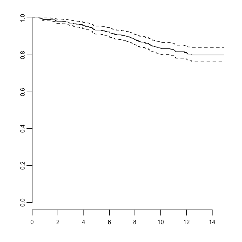

```r
thr <- 2
torontoX <- torontoX[,colSums(torontoX != 0)>=thr]

torontoGroups <- factor(names(torontoX) %in% c("age","gender")+1, level=1:2, labels=c("Genes","Demographics"))

torontoX$age <- torontoX$age/10
names(torontoX)[which(names(torontoX)=="age")] <- "age_10"
g <- torontoGroups == "Genes"
torontoX[,g] <- torontoX[,g]*10
names(torontoX)[g] <- paste(names(torontoX)[g], "0.1",sep="_")

torontoSurv <- Surv(time = torontoData$fu_years, event = torontoData$Diagnosis=="AML")
plot(survfit(torontoSurv~ 1))
```

# 4 Validation cohort

## 4.1 Data

```r
f = "data/VC_vaf_matrix_no_duplicates_262ctrl_29aml_nodates.csv"
sangerData <- read.csv(f)
colnames(sangerData)
```

```
##  [1] "X"          "Sample"     "ASXL1"      "BCOR"       "CBL"        "CEBPA"      "DNMT3A"     "IDH1"
##  [9] "IDH2"       "JAK2"       "KMT2C"      "KMT2D"      "KRAS"       "NF1"        "NRAS"       "PTPN11"
## [17] "RAD21"      "SF3B1"      "SRSF2"      "TET2"       "TP53"       "U2AF1"      "Individual" "hcdate"
## [25] "Diagnosis"  "age"        "gender"     "systol"     "diastol"    "bmi"        "cholestl"   "triglyc"
## [33] "hdl"        "ldl"        "lym"        "mcv"        "rdw"        "wbc"        "rbc"        "hct"
## [41] "plt"        "hgb"        "dodx"
```

```r
head(sangerData[, c("Sample", "gender")]) #male=1, female=0
```

|  | Sample | gender |
| --- | --- | --- |
| 1 | PD29762b | 0 |
| 2 | PD29764b | 0 |
| 3 | PD29792b | 0 |
| 4 | PD29804c | 0 |
| 5 | PD29810c | 1 |
| 6 | PD29836c | 0 |

NB all dates are jittered

```r
sangerData$hcdate <- as.Date(sangerData$hcdate)
sangerData$dodx <- as.Date(sangerData$dodx)

sangerPatients <- sub("[a-z]+$","", sangerData$Sample)
o <- order(sangerPatients, as.numeric(sangerData$hcdate))

sangerData <- sangerData[o,]
sangerPatients <- sangerPatients[o]

clinical_vars <- c("systol", "diastol", "bmi", "cholestl", "triglyc", "hdl", "ldl", "lym", "mcv", "rdw", "wbc", "plt", "hgb")
sangerX <- sangerData[, colnames(sangerData) %in% c(gene_vars, "age","gender",clinical_vars)]
sangerX <- as.data.frame(sangerX)

sangerX <- sangerX[,colSums(sangerX != 0,na.rm=TRUE)>=thr]
sangerGroups <- factor(grepl("^[a-z]", colnames(sangerX))*2, levels=0:2, labels=c("Genes", "Demographics", "Blood"))
sangerGroups[names(sangerX) %in% c("age","gender")] <- "Demographics"
table(sangerGroups)
```

```
## sangerGroups
##        Genes Demographics        Blood
##           15            2           13
```

```r
g <- sangerGroups=="Genes"
sangerX[g] <- sangerX[g] * 10
names(sangerX)[g] <- paste(names(sangerX[g]),"0.1", sep="_")
y <- StandardizeMagnitude(sangerX[!g])
sangerX <- cbind(sangerX[g],y)

poorMansImpute <- function(x) {x[is.na(x)] <- mean(x, na.rm=TRUE); return(x)}
sangerX <- as.data.frame(sapply(sangerX, poorMansImpute))

foo <- split(sangerData[,c("Diagnosis","hcdate","dodx")], sangerPatients)

bar <- do.call("rbind",lapply(foo, function(x){
                    y <- x
                    n <- nrow(y)
                    y[-n,"Diagnosis"] <- "Control"
                    start <- as.numeric(y$hcdate - y$hcdate[1])/365.25
                    end <- c(as.numeric(y$hcdate - y$hcdate[1])[-1]/365.25, as.numeric(y$dodx[n] - y$hcdate[1])/365.25)
                    return(data.frame(Diagnosis=y[,"Diagnosis"], start=start, end=end))
                }))

bar[1:6, ]
```

|  | Diagnosis | start | end |
| --- | --- | --- | --- |
| PD29762 | AML | 0 | 9.754962 |
| PD29764 | AML | 0 | 10.360027 |
| PD29792 | AML | 0 | 14.108145 |
| PD29804 | Control | 0 | 5.138946 |
| PD29810 | Control | 0 | 18.573580 |
| PD29836.1 | Control | 0 | 2.414784 |

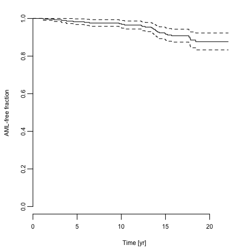

```r
sangerPatientsSplit <- unlist(sapply(names(foo), function(n) rep(n, nrow(foo[[n]]))))

sangerSurv <- Surv(time = bar$start, time2 = bar$end, event = bar$Diagnosis!="Control", origin = 0)
plot(survfit(sangerSurv ~ 1), ylab="AML-free fraction", xlab="Time [yr]")
```

# 5 Expected AML incidence

## 5.1 Validation cohort

```r
w <- c(which(sangerSurv[,1]==0)[-1]-1, nrow(sangerSurv))
head(sangerSurv[w,])
```

```
## [1] (0.000000, 9.754962]  (0.000000,10.360027]  (0.000000,14.108145]  (0.000000, 5.138946+] (0.000000,18.573580+]
## [6] (2.414784,10.023272]
```

```r
sangerSurv2 <- Surv(sangerSurv[w,2], sangerSurv[w,3])

expected_rate_sanger_cr <- mean(aml_inc_cr(sangerX[w,"gender"],sangerX[w,"age_10"]*10, sangerX[w,"age_10"]*10+ pmax(1,sangerSurv2[,1]))[!sangerSurv2[,2]])

n_total_sanger <- sum(sangerSurv2[,2])/expected_rate_sanger_cr
n_total_sanger
```

```
## [1] 10406.64
```

## 5.2 Discovery cohort

```r
expected_rate_toronto_cr <- mean(aml_inc_cr(torontoX[,"gender"],torontoX[,"age_10"]*10, torontoX[,"age_10"]*10+ pmax(1,torontoSurv[,1]))[!torontoSurv[,2]])

n_total_toronto <- sum(torontoSurv[,2])/expected_rate_toronto_cr
n_total_toronto
```

```
## [1] 72377.73
```

# 6 Combined data

Survival

```r
allSurv <- rbind(sangerSurv, Surv(rep(0, nrow(torontoSurv)), torontoSurv[,1], torontoSurv[,2]))
allSurv <- Surv(allSurv[,1], allSurv[,2], allSurv[,3])
```

Data matrix

```r
cohort <- c(rep("Sanger", nrow(sangerX)), rep("Toronto", nrow(torontoX)))
i <- c(sort(setdiff(gene_vars,"CALR")),"age","gender")
allX <- rbind(superSet(sangerData,i,fill=0), superSet(torontoData,i,fill=0))
colnames(allX)
```

```
##  [1] "ASXL1"  "BCOR"   "CBL"    "CEBPA"  "DNMT3A" "IDH1"   "IDH2"   "JAK2"   "KDM6A"  "KIT"    "KMT2C"  "KMT2D"
## [13] "KRAS"   "NF1"    "NRAS"   "PHF6"   "PTPN11" "RAD21"  "RUNX1"  "SF3B1"  "SRSF2"  "TET2"   "TP53"   "U2AF1"
## [25] "age"    "gender"
```

```r
allX <- allX[,colSums(allX>0)>=thr]
allX <- cbind(allX, cohort=cohort=="Sanger") + 0
allGroups <- factor(grepl("^[A-Z]",colnames(allX))+0, levels=1:0, labels=c("Genes","Demographics"))

g <- allGroups=="Genes"
allX <- cbind(10*allX[,g], StandardizeMagnitude(allX[,!g]))
colnames(allX)[g] <- paste(colnames(allX)[g],"0.1",sep="_")
control <- c(sangerData$Diagnosis=="Control", torontoData$Diagnosis=="Control")
```

Weights

```r
weights <- rep(1, nrow(allX))
weights[cohort=="Sanger" & control] <- n_total_sanger/sum(cohort=="Sanger" & control & allSurv[,1]==0)
weights[cohort=="Toronto" & control] <- n_total_toronto/sum(cohort=="Toronto" & control)

n_total <- n_total_sanger + n_total_toronto
n_total
```

```
## [1] 82784.38
```

Kaplan-Meier analysis

```r
X = allX
surv = allSurv
pal1 <- c("#C32B4A", "#3F76B4", "#57B2AB", "#5E4FA2", "#EB6046")

colnames(X)
```

```
##  [1] "ASXL1_0.1"  "BCOR_0.1"   "CBL_0.1"    "DNMT3A_0.1" "IDH1_0.1"   "IDH2_0.1"   "JAK2_0.1"   "KDM6A_0.1"
##  [9] "KMT2C_0.1"  "KMT2D_0.1"  "KRAS_0.1"   "NF1_0.1"    "NRAS_0.1"   "PHF6_0.1"   "PTPN11_0.1" "RAD21_0.1"
## [17] "RUNX1_0.1"  "SF3B1_0.1"  "SRSF2_0.1"  "TET2_0.1"   "TP53_0.1"   "U2AF1_0.1"  "age_10"     "gender"
## [25] "cohort"
```

```r
names(X) <- str_replace(names(X), "[_]{1}[0-9]{1,}[\\.]{0,1}[0-9]{0,2}", "")
X$no_drivers <- rowSums((X[, colnames(X) %in% gene_vars]>0))
summary(X$no_drivers)
```

```
##    Min. 1st Qu.  Median    Mean 3rd Qu.    Max.
##  0.0000  0.0000  0.0000  0.5263  1.0000  5.0000
```

```r
X$max_vaf <- apply(X[, intersect(gene_vars, colnames(X))], 1, max, na.rm = TRUE)

genes <- c("DNMT3A", "TET2", "TP53", "U2AF1")

n_drivers <- cut(X$no_drivers, c( -1, 0, 1,  max(X$no_drivers)))
levels(n_drivers) <- c(0,1,"2+")

mvaf <- cut(X$max_vaf*10, c( -1, 0, 4, 8, max(X$max_vaf*10)))  #multiply by 10 to reverse VAF standardisation
levels(mvaf) <- c("0", "0 - 4", "4 - 8", "8+")

par(mfrow=c(2,4), mar = c(1.8, 1.9, 1.7, 0.1) + 0.1, mgp=c(2.2,0.4,0), bty="L", xpd=TRUE, las=1, tcl=-0.15, cex.axis=1, cex.lab = 1)
for (i in 1:length(genes)) {
  #i <- 1
  gene <- genes[i]
  plot(survfit(surv ~ X[[gene]] == 0), col= pal1, bty='L', yaxs='i', ylim=c(0,1.01), mark.time = T, conf.int = F)
  mtext(gene, font=3, side = 3, line = 0.1, cex = 0.7)
  legend("bottomleft", col=pal1[1:2], lty=1, c("MT","WT"), lwd = 1.1, bty="n", ncol = 1, cex = 0.9)
}
plot(survfit(surv ~ n_drivers), col=rev(pal1[1:3]), conf.int = F, mark.time = T, bty='L', yaxs='i', ylim=c(0,1.01))
mtext("Number of drivers", font=1, side = 3, line = 0.4, cex = 0.7)
legend("bottomleft", legend = levels(n_drivers), col= rev(pal1[1:3]), lty=1, lwd = 1.1, bty='n', title="", cex = 0.9)
plot(survfit(surv ~ mvaf), col= rev(pal1[1:4]), conf.int = F, mark.time = T, bty='L', yaxs='i', ylim=c(0,1.01))
mtext("Maximum VAF (%)", font=1, side = 3, line = 0.4, cex = 0.7)
legend("bottomleft", levels(mvaf), col=rev(pal1[1:4]), lty=1, lwd = 1.1, bty='n', title="", cex = 0.9)

genes <- intersect(colnames(X), gene_vars)
length(genes)
```

[output not shown]

```
## [1] 22
```

```r
png("./figures/CombinedCohorts.KM.curves.png", width = 35, height = 20, units = "cm", res = 300)
par(mfrow=c(4,7), mar = c(3.7, 3.5, 1.6, 1) + 0.1, mgp=c(1.9,0.4,0), bty="L", xpd=TRUE, las=1, tcl=-0.2, cex.axis=1, cex.lab = 1.2)
for (i in 1:length(genes)) {
  #i <- 1
  gene <- genes[i]
  plot(survfit(surv ~ X[[gene]] == 0), col= pal1, xlab='Time (years)', ylab = 'AML-free fraction', bty='L', yaxs='i', ylim=c(0,1.01), mark.time = T, conf.int = F)
  mtext(gene, font=4, side = 3, cex = 0.9, line = 0.35)
}
plot.new(); par(xpd=NA)
legend(x = -0.5, y = 0.5, col=pal1[1:2], lty=1, c("Mutated","Wildtype"), cex=1.4, lwd = 2, bty="n", ncol = 1)
dev.off()
```

# 7 Coxph model fits

```r
sigma0 <- 0.1
nu <- 1
which.mu <- "Genes"
```

## 7.1 Discovery cohort

### 7.1.1 Non-adjusted

```r
fitToronto <- CoxRFX(torontoX, torontoSurv, groups=torontoGroups, which.mu=which.mu, nu=nu, sigma0=sigma0)
waldToronto <- WaldTest(fitToronto)
```

```
##                   group    coef   coef-mu     sd      z df  p.value sig
## ASXL1_0.1         Genes  0.6715  3.40e-02 0.1169  5.745  1 9.19e-09 ***
## CALR_0.1          Genes  0.6168 -2.07e-02 0.0717  8.603  1 7.76e-18 ***
## CBL_0.1           Genes  0.5158 -1.22e-01 0.1311  3.935  1 8.30e-05 ***
## DNMT3A_0.1        Genes  0.5860 -5.15e-02 0.1017  5.761  1 8.36e-09 ***
## IDH1_0.1          Genes  0.6818  4.43e-02 0.1269  5.373  1 7.74e-08 ***
## IDH2_0.1          Genes  0.5153 -1.22e-01 0.1159  4.446  1 8.74e-06 ***
## JAK2_0.1          Genes  0.6967  5.92e-02 0.1249  5.580  1 2.40e-08 ***
## KDM6A_0.1         Genes  0.6375  2.36e-05 0.0581 10.982  1 4.67e-28 ***
## KMT2C_0.1         Genes  0.6602  2.27e-02 0.0618 10.689  1 1.14e-26 ***
## KRAS_0.1          Genes  0.6350 -2.46e-03 0.0581 10.932  1 8.12e-28 ***
## NF1_0.1           Genes  0.6359 -1.61e-03 0.0581 10.947  1 6.86e-28 ***
## PHF6_0.1          Genes  0.6429  5.40e-03 0.0586 10.978  1 4.87e-28 ***
## PTPN11_0.1        Genes  0.6546  1.71e-02 0.0583 11.224  1 3.11e-29 ***
## RUNX1_0.1         Genes  0.3926 -2.45e-01 0.0927  4.236  1 2.27e-05 ***
## SF3B1_0.1         Genes  0.7605  1.23e-01 0.1045  7.274  1 3.49e-13 ***
## SRSF2_0.1         Genes  0.4847 -1.53e-01 0.0944  5.134  1 2.83e-07 ***
## TET2_0.1          Genes  0.6127 -2.48e-02 0.1300  4.712  1 2.46e-06 ***
## TP53_0.1          Genes  0.8595  2.22e-01 0.0875  9.823  1 8.99e-23 ***
## U2AF1_0.1         Genes  0.8524  2.15e-01 0.0785 10.860  1 1.79e-27 ***
## age_10     Demographics -0.0387 -3.87e-02 0.0943 -0.410  1 6.82e-01
## gender     Demographics -0.0434 -4.34e-02 0.1069 -0.406  1 6.85e-01
```

```r
survConcordance(fitToronto$surv ~ fitToronto$linear.predictors)
```

```
## Call:
## survConcordance(formula = fitToronto$surv ~ fitToronto$linear.predictors)
##
##   n= 505
## Concordance= 0.7426378 se= 0.03079247
## concordant discordant  tied.risk  tied.time   std(c-d)
##  28925.000  10024.000      0.000      1.000   2398.672
```

### 7.1.2 Adjusted

```r
fitWeightedToronto <- CoxRFX(torontoX, torontoSurv, torontoGroups, which.mu=which.mu, sigma0=sigma0, nu=nu, weights=weights[cohort=="Toronto"])
waldWeightedToronto <- WaldTest(fitWeightedToronto)
```

```
##                   group    coef coef-mu     sd      z df  p.value sig
## ASXL1_0.1         Genes  1.9481  0.0184 0.1452 13.415  1 4.92e-41 ***
## CALR_0.1          Genes  0.8664 -1.0633 0.7205  1.202  1 2.29e-01
## CBL_0.1           Genes  0.3846 -1.5451 0.3618  1.063  1 2.88e-01
## DNMT3A_0.1        Genes  0.7091 -1.2206 0.1236  5.736  1 9.70e-09 ***
## IDH1_0.1          Genes  2.3976  0.4679 0.3353  7.151  1 8.63e-13 ***
## IDH2_0.1          Genes  0.8112 -1.1185 0.2286  3.548  1 3.88e-04 ***
## JAK2_0.1          Genes  1.9253 -0.0044 0.1819 10.586  1 3.45e-26 ***
## KDM6A_0.1         Genes  1.9404  0.0107 0.1355 14.323  1 1.56e-46 ***
## KMT2C_0.1         Genes  2.4139  0.4841 0.6457  3.739  1 1.85e-04 ***
## KRAS_0.1          Genes  1.8253 -0.1044 0.1565 11.665  1 1.93e-31 ***
## NF1_0.1           Genes  1.8627 -0.0670 0.1522 12.238  1 1.94e-34 ***
## PHF6_0.1          Genes  2.1738  0.2441 0.1301 16.706  1 1.19e-62 ***
## PTPN11_0.1        Genes  2.5509  0.6212 0.2150 11.867  1 1.76e-32 ***
## RUNX1_0.1         Genes  0.7839 -1.1458 0.1361  5.761  1 8.38e-09 ***
## SF3B1_0.1         Genes  3.1354  1.2057 0.3087 10.156  1 3.11e-24 ***
## SRSF2_0.1         Genes  1.3985 -0.5312 0.1706  8.196  1 2.49e-16 ***
## TET2_0.1          Genes  0.6793 -1.2504 0.2014  3.373  1 7.43e-04 ***
## TP53_0.1          Genes  4.8882  2.9585 0.4224 11.572  1 5.69e-31 ***
## U2AF1_0.1         Genes  3.9699  2.0402 0.3601 11.024  1 2.94e-28 ***
## age_10     Demographics -0.0869 -0.0869 0.0996 -0.872  1 3.83e-01
## gender     Demographics -0.0443 -0.0443 0.1112 -0.399  1 6.90e-01
```

```r
survConcordance(fitWeightedToronto$surv ~ fitWeightedToronto$linear.predictors, weights=weights[cohort=="Toronto"])
```

```
## Call:
## survConcordance(formula = fitWeightedToronto$surv ~ fitWeightedToronto$linear.predictors,
##     weights = weights[cohort == "Toronto"])
##
##   n= 505
## Concordance= 0.7739557 se= 0.03055735
## concordant discordant  tied.risk  tied.time   std(c-d)
##  4719299.0  1378335.7        0.0        1.0   372655.1
```

Uno’s estimator of cumulative/dynamic AUC

```r
a <- AUC.uno(torontoSurv, torontoSurv, fitWeightedToronto$linear.predictors, times= seq(0,12, 0.1))
round(a$iauc, digits = 3)
```

```
## [1] 0.761
```

```r
png("./figures/DC.adj.coxph.auc.uno.png", width = 9, height = 10, units = "cm", res = 800)
par(mar = c(3.2, 3.2, 4, 2) + 0.1, mgp=c(2,0.5,0), bty="L",  tcl =-0.2, las = 1, cex=1)
plot(a$times, a$auc, xlab="Time (years)", ylab="AUC", pch=16, col="grey80", ylim = c(0,1.0))
lines(a$times, predict(loess(a$auc ~ a$times, span=0.25)))
abline(h=a$iauc, lty = 3, lwd = 1)
legend("bottomright", bty = "n", cex = 1.2, legend = paste("AUC = ",round(a$iauc,2)))
dev.off()
```

Time-dependent ROC AUC

```r
r <- survivalROC(Stime = torontoSurv[,1], status=torontoSurv[,2], marker=fitWeightedToronto$linear.predictors-colMeans(fitWeightedToronto$Z) %*% fitWeightedToronto$coefficients, predict.time = 10, method="NNE", span=0.001)
round(r$AUC, digits = 3)
```

```
## [1] 0.783
```

```r
png("./figures/DC.adj.coxph.roct.png", width = 9, height = 10, units = "cm", res = 500)
par(mar = c(3.2, 3.2, 4, 2) + 0.1, mgp=c(2,0.5,0), bty="L",  tcl =-0.2, las = 1, cex = 1)
plot(r$FP, r$TP, type='s',
     xlab="False Positive Rate", ylab="True Positive Rate",
     col = "black")
abline(a = 0, b = 1, col = "grey70", lty = 1, lwd = 1)
legend("bottomright", bty = "n", legend = paste("AUC = ",round(r$AUC,2)))
dev.off()
```

## 7.2 Validation cohort

### 7.2.1 Non-adjusted

```r
fitSanger <- CoxRFX(sangerX, sangerSurv, groups=sangerGroups, which.mu=which.mu, nu=nu, sigma0=sigma0)
waldSanger <- WaldTest(fitSanger)
```

```
##                    group     coef   coef-mu      sd       z df  p.value sig
## ASXL1_0.1          Genes  0.76929  0.138331 0.11468  6.7084  1 1.97e-11 ***
## CBL_0.1            Genes  0.62044 -0.010519 0.09149  6.7814  1 1.19e-11 ***
## DNMT3A_0.1         Genes  0.51590 -0.115058 0.11678  4.4176  1 9.98e-06 ***
## JAK2_0.1           Genes  0.58502 -0.045941 0.10315  5.6716  1 1.42e-08 ***
## KMT2C_0.1          Genes  0.64589  0.014930 0.08616  7.4961  1 6.57e-14 ***
## KMT2D_0.1          Genes  0.50507 -0.125896 0.15209  3.3209  1 8.97e-04 ***
## KRAS_0.1           Genes  0.63604  0.005083 0.08495  7.4876  1 7.02e-14 ***
## NF1_0.1            Genes  0.62556 -0.005397 0.08610  7.2657  1 3.71e-13 ***
## NRAS_0.1           Genes  0.63025 -0.000712 0.08492  7.4214  1 1.16e-13 ***
## RAD21_0.1          Genes  0.62875 -0.002212 0.08524  7.3763  1 1.63e-13 ***
## SF3B1_0.1          Genes  0.62728 -0.003678 0.08572  7.3181  1 2.52e-13 ***
## SRSF2_0.1          Genes  0.58180 -0.049163 0.12680  4.5883  1 4.47e-06 ***
## TET2_0.1           Genes  0.69969  0.068723 0.11185  6.2555  1 3.96e-10 ***
## TP53_0.1           Genes  0.69326  0.062294 0.08559  8.0998  1 5.51e-16 ***
## U2AF1_0.1          Genes  0.70018  0.069214 0.08556  8.1832  1 2.76e-16 ***
## age_10      Demographics  0.10777  0.107774 0.12063  0.8934  1 3.72e-01
## gender      Demographics  0.00589  0.005894 0.10667  0.0553  1 9.56e-01
## systol_100         Blood  0.03002  0.030016 0.04429  0.6777  1 4.98e-01
## diastol_100        Blood  0.04718  0.047181 0.02863  1.6478  1 9.94e-02   .
## bmi_10             Blood  0.14183  0.141832 0.07973  1.7790  1 7.52e-02   .
## cholestl_10        Blood  0.00525  0.005246 0.01501  0.3496  1 7.27e-01
## triglyc            Blood  0.00450  0.004496 0.10599  0.0424  1 9.66e-01
## hdl                Blood -0.09452 -0.094522 0.08059 -1.1729  1 2.41e-01
## ldl                Blood  0.11424  0.114236 0.11019  1.0367  1 3.00e-01
## lym                Blood  0.10961  0.109610 0.10081  1.0872  1 2.77e-01
## mcv_100            Blood -0.01645 -0.016447 0.00817 -2.0136  1 4.41e-02   *
## rdw_10             Blood  0.06116  0.061157 0.01972  3.1015  1 1.93e-03  **
## wbc_10             Blood  0.01499  0.014994 0.04138  0.3623  1 7.17e-01
## plt_100            Blood  0.06837  0.068369 0.09739  0.7020  1 4.83e-01
## hgb_10             Blood  0.04890  0.048900 0.02466  1.9826  1 4.74e-02   *
```

```r
survConcordance(sangerSurv ~ fitSanger$linear.predictors)
```

```
## Call:
## survConcordance(formula = sangerSurv ~ fitSanger$linear.predictors)
##
##   n= 445
## Concordance= 0.793915 se= 0.05514512
## concordant discordant  tied.risk  tied.time   std(c-d)
##  5532.0000  1436.0000     0.0000     0.0000   768.5024
```

### 7.2.2 Adjusted

```r
fitWeightedSanger <- CoxRFX(sangerX, sangerSurv, sangerGroups, which.mu=which.mu, sigma0=sigma0, nu=nu, weights=weights[cohort=="Sanger"])
waldWeightedSanger <- WaldTest(fitWeightedSanger)
```

```
##                    group     coef  coef-mu      sd       z df  p.value sig
## ASXL1_0.1          Genes  2.93589  0.95179 0.45155  6.5018  1 7.93e-11 ***
## CBL_0.1            Genes  0.89451 -1.08959 1.25454  0.7130  1 4.76e-01
## DNMT3A_0.1         Genes  0.80635 -1.17775 0.22686  3.5544  1 3.79e-04 ***
## JAK2_0.1           Genes -0.33650 -2.32060 0.95076 -0.3539  1 7.23e-01
## KMT2C_0.1          Genes  2.07422  0.09012 1.10633  1.8749  1 6.08e-02   .
## KMT2D_0.1          Genes  0.05067 -1.93343 0.81191  0.0624  1 9.50e-01
## KRAS_0.1           Genes  2.45194  0.46784 0.41069  5.9702  1 2.37e-09 ***
## NF1_0.1            Genes  1.54402 -0.44008 0.90581  1.7046  1 8.83e-02   .
## NRAS_0.1           Genes  1.92976 -0.05434 0.37569  5.1366  1 2.80e-07 ***
## RAD21_0.1          Genes  1.75445 -0.22966 0.66215  2.6496  1 8.06e-03  **
## SF3B1_0.1          Genes  1.56640 -0.41770 0.99531  1.5738  1 1.16e-01
## SRSF2_0.1          Genes  1.51230 -0.47181 0.27893  5.4217  1 5.90e-08 ***
## TET2_0.1           Genes  1.31638 -0.66772 0.13659  9.6374  1 5.56e-22 ***
## TP53_0.1           Genes  4.92658  2.94248 0.92037  5.3528  1 8.66e-08 ***
## U2AF1_0.1          Genes  6.33456  4.35046 0.76145  8.3191  1 8.86e-17 ***
## age_10      Demographics  0.03788  0.03788 0.11866  0.3193  1 7.50e-01
## gender      Demographics -0.01411 -0.01411 0.10079 -0.1400  1 8.89e-01
## systol_100         Blood  0.01712  0.01712 0.04486  0.3816  1 7.03e-01
## diastol_100        Blood  0.03900  0.03900 0.02964  1.3156  1 1.88e-01
## bmi_10             Blood  0.15297  0.15297 0.08406  1.8198  1 6.88e-02   .
## cholestl_10        Blood  0.00238  0.00238 0.01544  0.1542  1 8.77e-01
## triglyc            Blood -0.03451 -0.03451 0.11758 -0.2935  1 7.69e-01
## hdl                Blood -0.12128 -0.12128 0.08447 -1.4357  1 1.51e-01
## ldl                Blood  0.13215  0.13215 0.11436  1.1555  1 2.48e-01
## lym                Blood  0.07976  0.07976 0.10326  0.7724  1 4.40e-01
## mcv_100            Blood -0.02401 -0.02401 0.00786 -3.0529  1 2.27e-03  **
## rdw_10             Blood  0.06721  0.06721 0.01666  4.0355  1 5.45e-05 ***
## wbc_10             Blood  0.00757  0.00757 0.04834  0.1567  1 8.76e-01
## plt_100            Blood  0.08415  0.08415 0.09986  0.8427  1 3.99e-01
## hgb_10             Blood  0.03718  0.03718 0.02437  1.5255  1 1.27e-01
```

```r
waldWeightedSanger$p.adj <- p.adjust(p=waldWeightedSanger$p.value, method = "bonferroni")
#View(waldWeightedSanger)

survConcordance(sangerSurv ~ fitWeightedSanger$linear.predictors, weights=weights[cohort=="Sanger"])
```

```
## Call:
## survConcordance(formula = sangerSurv ~ fitWeightedSanger$linear.predictors,
##     weights = weights[cohort == "Sanger"])
##
##   n= 445
## Concordance= 0.8351691 se= 0.05475847
## concordant discordant  tied.risk  tied.time   std(c-d)
##  218019.86   43028.90       0.00       0.00   28589.26
```

Uno’s estimator of cumulative/dynamic AUC

```r
w <- c(which(sangerSurv[,1]==0)[-1]-1, nrow(sangerSurv))  #get right censored survival data for each individual
s <- Surv(sangerSurv[w,2], sangerSurv[w,3])  ##Adjust according to dimensions of survival object
a <- AUC.uno(s, s, fitWeightedSanger$linear.predictors[w], times= seq(0, 22, 0.1))
round(a$iauc, digits = 3)
```

```
## [1] 0.82
```

```r
png("./figures/VC.ajd.coxph.auc.uno.png", width = 9, height = 10, units = "cm", res = 500)
par(mar = c(3.2, 3.2, 4, 2) + 0.1, mgp=c(2,0.5,0), bty="L",  tcl =-0.2, las = 1, cex=1)
plot(a$times, a$auc, xlab="Time (years)", ylab="AUC", pch=16, col="grey80", ylim = c(0,1.0))
lines(a$times, predict(loess(a$auc ~ a$times, span=0.25)))
abline(h=a$iauc, lty = 3, lwd = 1)
legend("bottomright", bty = "n", legend = paste("AUC = ",round(a$iauc,2)))
dev.off()
```

Time-dependent ROC AUC

```r
r <- survivalROC(Stime = s[,1], status=s[,2], marker=fitWeightedSanger$linear.predictors[w]-colMeans(fitWeightedSanger$Z[w,]) %*% fitWeightedSanger$coefficients, predict.time = 10, method="NNE", span=0.001)
round(r$AUC, digits = 3)
```

```
## [1] 0.737
```

```r
png("./figures/VC.ajd.coxph.roct.png", width = 9, height = 10, units = "cm", res = 500)
par(mar = c(3.2, 3.2, 4, 2) + 0.1, mgp=c(2,0.5,0), bty="L",  tcl =-0.2, las = 1, cex = 1)
plot(r$FP, r$TP, type='s',
     xlab="False Positive Rate", ylab="True Positive Rate",
     col = "black")
abline(a = 0, b = 1, col = "grey70", lty = 1, lwd = 1)
legend("bottomright", bty = "n", legend = paste("AUC = ",round(r$AUC,2)))
dev.off()
```

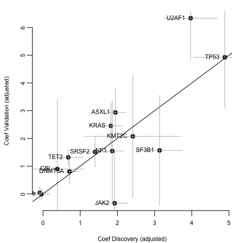

```r
i <- intersect(rownames(waldWeightedSanger), rownames(waldWeightedToronto))
plot( waldWeightedToronto[i,"coef"], waldWeightedSanger[i, "coef"], xlab="Coef Discovery (adjusted)", ylab="Coef Validation (adjusted)", pch=19, cex=1)
segments(waldWeightedToronto[i,"coef"]  - 2*waldWeightedToronto[i,"sd"], waldWeightedSanger[i, "coef"], waldWeightedToronto[i,"coef"]  + 2*waldWeightedToronto[i,"sd"], waldWeightedSanger[i, "coef"], col="grey" )
segments(waldWeightedToronto[i,"coef"]  , waldWeightedSanger[i, "coef"]-  2*waldWeightedSanger[i,"sd"], waldWeightedToronto[i,"coef"] , waldWeightedSanger[i, "coef"] +2*waldWeightedSanger[i,"sd"], col="grey")
text(labels=sub("_.+","", i), waldWeightedToronto[i,"coef"], waldWeightedSanger[i, "coef"], pos=2, adj=c(0,1))
abline(0,1)
```

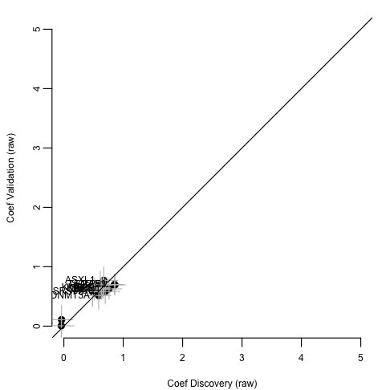

```r
plot( waldToronto[i,"coef"], waldSanger[i, "coef"], xlab="Coef Discovery (raw)", ylab="Coef Validation (raw)", pch=19, cex=1, ylim=c(0,5),xlim=c(0,5))
segments(waldToronto[i,"coef"]  - 2*waldToronto[i,"sd"], waldSanger[i, "coef"], waldToronto[i,"coef"]  + 2*waldToronto[i,"sd"], waldSanger[i, "coef"], col="grey" )
segments(waldToronto[i,"coef"]  , waldSanger[i, "coef"]-  2*waldSanger[i,"sd"], waldToronto[i,"coef"] , waldSanger[i, "coef"] +2*waldSanger[i,"sd"], col="grey")
text(labels=sub("_.+","", i), waldToronto[i,"coef"], waldSanger[i, "coef"], pos=2, adj=c(0,1))
abline(0,1)
```

## 7.3 Cross-validation

### 7.3.1 Non-adjusted

```r
sangerImp <- torontoX[1:nrow(sangerX),]
sangerImp[,] <- NA
i <- intersect(names(sangerX),colnames(torontoX))
sangerImp[,i] <- sangerX[,i]
j <- setdiff(names(torontoX)[torontoGroups=="Genes"], names(sangerX))
sangerImp[,j] <- 0
```

DC fit, VC data

```r
pS <- PredictRiskMissing(fitToronto, sangerImp)
survConcordance(sangerSurv ~ pS[,1])
```

```
## Call:
## survConcordance(formula = sangerSurv ~ pS[, 1])
##
##   n= 445
## Concordance= 0.7963548 se= 0.05514445
## concordant discordant  tied.risk  tied.time   std(c-d)
##   5545.000   1415.000      8.000      0.000    768.493
```

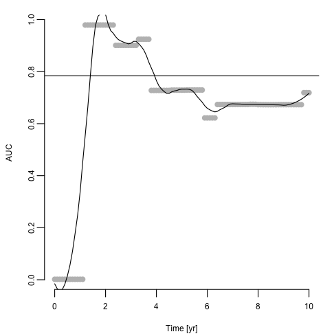

```r
w <- c(which(sangerSurv[,1]==0)[-1]-1, nrow(sangerSurv))
s <- Surv(sangerSurv[w,2], sangerSurv[w,3])
t <- seq(0,10,0.1)
a <- AUC.uno(torontoSurv, s, pS[w,1], times=t)
plot(a$times, a$auc, xlab="Time [yr]", ylab="AUC", pch=16, col='grey')
lines(a$times, predict(loess(a$auc ~ a$times, span=0.25)))
abline(h=a$iauc)
```

```r
torontoImp <- sangerX[1:nrow(torontoX),]
torontoImp[,] <- NA
i <- intersect(names(sangerX),colnames(torontoX))
torontoImp[,i] <- torontoX[,i]
j <- setdiff(names(sangerX)[sangerGroups=="Genes"], names(torontoX))
torontoImp[,j] <- 0
```

VC fit, DC data

```r
pT <- PredictRiskMissing(fitSanger, torontoImp)
survConcordance(torontoSurv ~ pT[,1])
```

```
## Call:
## survConcordance(formula = torontoSurv ~ pT[, 1])
##
##   n= 505
## Concordance= 0.6992477 se= 0.03079247
## concordant discordant  tied.risk  tied.time   std(c-d)
##  27235.000  11714.000      0.000      1.000   2398.672
```

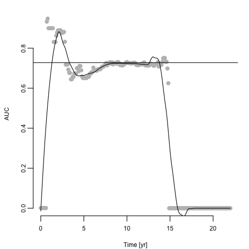

```r
t <- seq(0,22,0.1)
a <- AUC.uno(s, torontoSurv, pT[,1], times=t)
plot(a$times, a$auc, xlab="Time [yr]", ylab="AUC", pch=16, col='grey')
lines(a$times, predict(loess(a$auc ~ a$times, span=0.25)))
abline(h=a$iauc)
```

```r
sangerM <- sangerX
sangerM[,sangerGroups=="Blood"] <- NA
p <- PredictRiskMissing(fitSanger, sangerM)
survConcordance(sangerSurv ~ p[,1])
```

```
## Call:
## survConcordance(formula = sangerSurv ~ p[, 1])
##
##   n= 445
## Concordance= 0.8069747 se= 0.05514449
## concordant discordant  tied.risk  tied.time   std(c-d)
##  5619.0000  1341.0000     8.0000     0.0000   768.4936
```

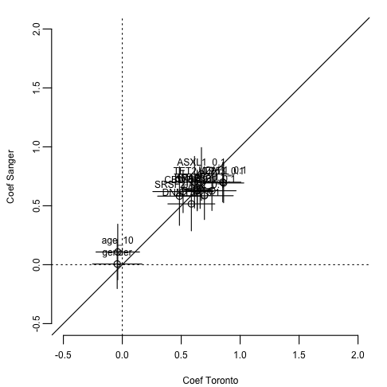

```r
plot(waldToronto[i,"coef"], waldSanger[i,"coef"], xlab="Coef Toronto", ylab="Coef Sanger", xlim=c(-0.5,2), ylim=c(-0.5,2))
text(labels=i,waldToronto[i,"coef"], waldSanger[i,"coef"], pos=3)
segments(x0=waldToronto[i,"coef"], x1=waldToronto[i,"coef"], y0= waldSanger[i,"coef"]-1.96*waldSanger[i,"sd"], y1=waldSanger[i,"coef"]+1.96*waldSanger[i,"sd"])
segments(x0=waldToronto[i,"coef"]-1.96*waldToronto[i,"sd"], x1=waldToronto[i,"coef"]+1.96*waldToronto[i,"sd"], y0= waldSanger[i,"coef"], y1=waldSanger[i,"coef"])
abline(0,1)
abline(h=0, lty=3)
abline(v=0, lty=3)
```

### 7.3.2 Adjusted

DC fit, VC data

```r
pS <- PredictRiskMissing(fitWeightedToronto, sangerImp)
survConcordance(sangerSurv ~ pS[,1], weights=weights[cohort=="Sanger"])
```

```
## Call:
## survConcordance(formula = sangerSurv ~ pS[, 1], weights = weights[cohort ==
##     "Sanger"])
##
##   n= 445
## Concordance= 0.821456 se= 0.05475772
##  concordant  discordant   tied.risk   tied.time    std(c-d)
## 214281.1753  46449.8206    317.7601      0.0000  28588.8682
```

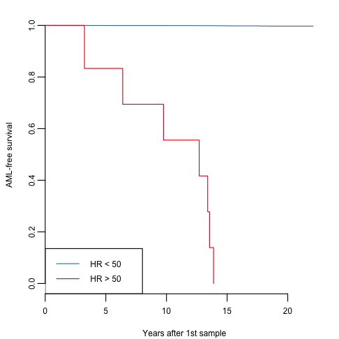

```r
m <- as.numeric(colSums(fitWeightedToronto$Z * weights[cohort=="Toronto"])/sum(weights[cohort=="Toronto"])) %*% coef(fitWeightedToronto)
plot(survfit(sangerSurv ~ exp(pS[,1]-as.numeric(m))>50, weights=weights[cohort=="Sanger"]), col=set1[2:1], ylab="AML-free survival", xlab='Years after 1st sample')
legend("bottomleft", c("HR < 50", "HR > 50"), lty=1, col=set1[2:1])
```

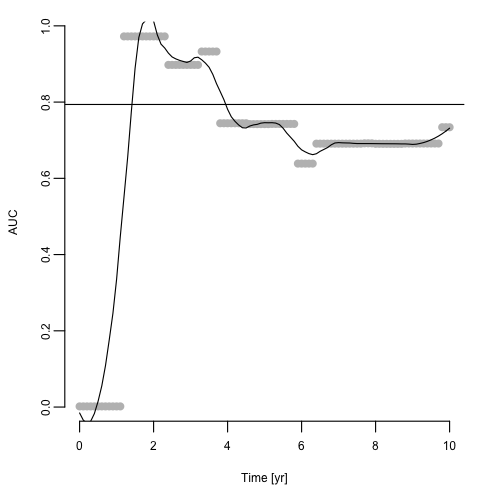

```r
w <- c(which(sangerSurv[,1]==0)[-1]-1, nrow(sangerSurv))
s <- Surv(sangerSurv[w,2], sangerSurv[w,3])
t <- seq(0,10,0.1)
a <- AUC.uno(torontoSurv, s, pS[w,1], times=t)
plot(a$times, a$auc, xlab="Time [yr]", ylab="AUC", pch=16, col='grey')
lines(a$times, predict(loess(a$auc ~ a$times, span=0.25)))
abline(h=a$iauc)
```

```r
png("./figures/DCfit.VCdata.adj.coxph.auc.uno.png", width = 14, height = 14, units = "cm", res = 500)
par(mar = c(4, 4, 4, 2) + 0.1, mgp=c(2.7,0.7,0), bty="L",  tcl =-0.2, las = 1, cex.lab = 1.1)
plot(a$times, a$auc, xlab="Time (years)", ylab="AUC", pch=16, col="grey80", ylim = c(0,1.0))
lines(a$times, predict(loess(a$auc ~ a$times, span=0.25)))
abline(h=a$iauc, lty = 3, lwd = 1)
mtext("DC fit, VC data", font= 2, side = 3, cex = 1, line = 0.5)
legend("bottomright", bty = "n", cex = 1.2, legend = paste("AUC = ",round(a$iauc,2)))
dev.off()
```

VC fit, DC data

```r
pT <- PredictRiskMissing(fitWeightedSanger, torontoImp)
survConcordance(torontoSurv ~ pT[,1], weights=weights[cohort=="Toronto"])
```

```
## Call:
## survConcordance(formula = torontoSurv ~ pT[, 1], weights = weights[cohort ==
##     "Toronto"])
##
##   n= 505
## Concordance= 0.7202544 se= 0.03055735
## concordant discordant  tied.risk  tied.time   std(c-d)
##  4391848.0  1705786.7        0.0        1.0   372655.1
```

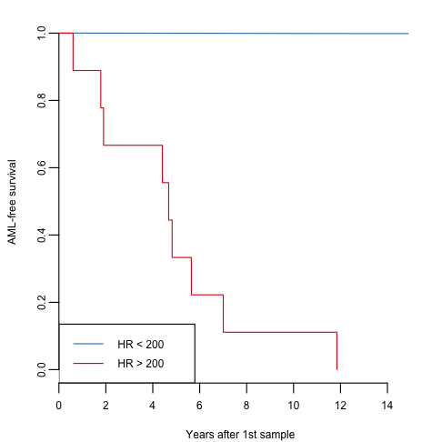

```r
m <- as.numeric(colSums(fitWeightedSanger$Z * weights[cohort=="Sanger"])/sum(weights[cohort=="Sanger"])) %*% coef(fitWeightedSanger)
plot(survfit(torontoSurv ~ exp(pT[,1]-as.numeric(m))>200, weights=weights[cohort=="Toronto"]), col=set1[2:1], ylab="AML-free survival", xlab='Years after 1st sample')
legend("bottomleft", c("HR < 200", "HR > 200"), lty=1, col=set1[2:1])
```

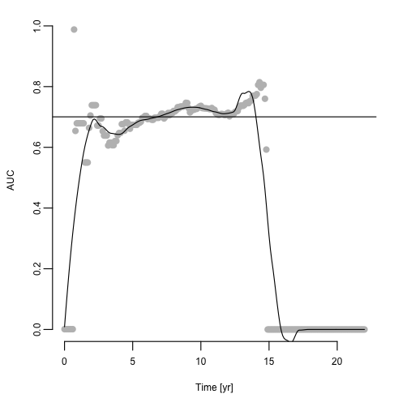

```r
t <- seq(0,22,0.1)
a <- AUC.uno(s, torontoSurv, pT[,1], times=t)
plot(a$times, a$auc, xlab="Time [yr]", ylab="AUC", pch=16, col='grey')
lines(a$times, predict(loess(a$auc ~ a$times, span=0.25)))
abline(h=a$iauc)
```

```r
png("./figures/VCfit.DCdata.adj.coxph.auc.uno.png", width = 14, height = 14, units = "cm", res = 500)
par(mar = c(4, 4, 4, 2) + 0.1, mgp=c(2.7,0.7,0), bty="L",  tcl =-0.2, las = 1, cex.lab = 1.1)
plot(a$times, a$auc, xlab="Time (years)", ylab="AUC", pch=16, col="grey80", ylim = c(0,1.0))
lines(a$times, predict(loess(a$auc ~ a$times, span=0.25)))
abline(h=a$iauc, lty = 3, lwd = 1)
mtext("VC fit, DC data", font= 2, side = 3, cex = 1, line = 0.5)
legend("bottomright", bty = "n", cex = 1.2, legend = paste("AUC = ",round(a$iauc,2)))#dev.off()
dev.off()
```

## 7.4 Combined

### 7.4.1 Non-adjusted

```r
fitAll <- CoxRFX(allX, allSurv, allGroups, which.mu=which.mu, sigma0=sigma0, nu=nu)
fitAll
```

```
## Means:
##              mean    sd  z   p.val sig
## Genes        0.79 0.068 12 3.9e-31 ***
## Demographics 0.00 0.000  0      NA
##
## Variances - p-values only indicative:
##              sigma2 chisq  df   p.val sig
## Genes          0.19    25 9.2 2.7e-03  **
## Demographics   0.48    25 2.7 1.2e-05 ***
##
## Partial log hazard:
##              Cov[g,g] Sum(Cov[,g])   MSE
## Genes            0.40         0.41 0.012
## Demographics     0.45         0.46 0.032
## TOTAL             NaN         0.88 0.044
```

```r
WaldTest(fitAll, uncentered=FALSE)
```

```
##                        group      coef coef-mu      sd       z df  p.value sig
## ASXL1_0.1              Genes -0.042129 -0.8326 0.12580 -0.3349  1 7.38e-01
## BCOR_0.1               Genes  0.018602 -0.7719 0.00792  2.3484  1 1.89e-02   *
## CBL_0.1                Genes -0.313214 -1.1037 0.20346 -1.5394  1 1.24e-01
## DNMT3A_0.1             Genes -0.233727 -1.0242 0.10840 -2.1561  1 3.11e-02   *
## IDH1_0.1               Genes  0.021937 -0.7685 0.20020  0.1096  1 9.13e-01
## IDH2_0.1               Genes -0.278283 -1.0687 0.15309 -1.8177  1 6.91e-02   .
## JAK2_0.1               Genes -0.030573 -0.8210 0.14841 -0.2060  1 8.37e-01
## KDM6A_0.1              Genes  0.000538 -0.7899 0.00638  0.0843  1 9.33e-01
## KMT2C_0.1              Genes  0.068877 -0.7216 0.08598  0.8011  1 4.23e-01
## KMT2D_0.1              Genes -0.391241 -1.1817 0.20457 -1.9125  1 5.58e-02   .
## KRAS_0.1               Genes  0.006235 -0.7842 0.01271  0.4907  1 6.24e-01
## NF1_0.1                Genes -0.020208 -0.8107 0.03223 -0.6270  1 5.31e-01
## NRAS_0.1               Genes  0.034555 -0.7559 0.01285  2.6887  1 7.17e-03  **
## PHF6_0.1               Genes  0.016466 -0.7740 0.01532  1.0749  1 2.82e-01
## PTPN11_0.1             Genes  0.360022 -0.4304 0.20817  1.7295  1 8.37e-02   .
## RAD21_0.1              Genes -0.006662 -0.7971 0.01823 -0.3654  1 7.15e-01
## RUNX1_0.1              Genes -0.399568 -1.1900 0.11410 -3.5019  1 4.62e-04 ***
## SF3B1_0.1              Genes  0.239576 -0.5509 0.20922  1.1451  1 2.52e-01
## SRSF2_0.1              Genes -0.290822 -1.0813 0.13577 -2.1420  1 3.22e-02   *
## TET2_0.1               Genes -0.158347 -0.9488 0.10442 -1.5165  1 1.29e-01
## TP53_0.1               Genes  0.686128 -0.1043 0.19933  3.4423  1 5.77e-04 ***
## U2AF1_0.1              Genes  0.711837 -0.0786 0.19998  3.5595  1 3.72e-04 ***
## age_10          Demographics -0.034319 -0.0343 0.10560 -0.3250  1 7.45e-01
## gender          Demographics -0.096757 -0.0968 0.18251 -0.5302  1 5.96e-01
## cohort          Demographics -1.297202 -1.2972 0.24120 -5.3781  1 7.53e-08 ***
## mu.Genes                  NA  0.790457      NA      NA      NA  1       NA
## mu.Demographics           NA  0.000000      NA      NA      NA  1       NA
```

```r
survConcordance(allSurv ~ fitAll$linear.predictors)
```

```
## Call:
## survConcordance(formula = allSurv ~ fitAll$linear.predictors)
##
##   n= 950
## Concordance= 0.8059859 se= 0.02746324
## concordant discordant  tied.risk  tied.time   std(c-d)
##  61799.000  14873.000      8.000      1.000   4211.763
```

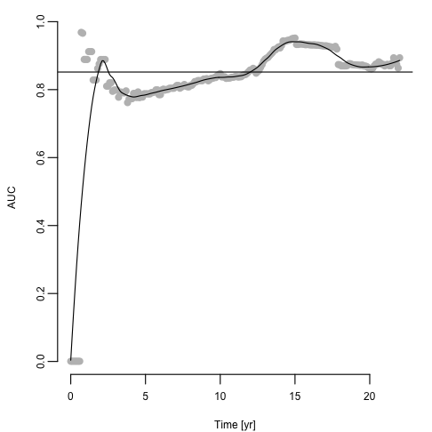

```r
w <- c(which(allSurv[,1]==0)[-1]-1, nrow(allSurv))
s <- Surv(allSurv[w,2], allSurv[w,3])
t <- seq(0,22,0.1)
a <- AUC.uno(s, s, fitAll$linear.predictors[w], times=t)
plot(a$times, a$auc, xlab="Time [yr]", ylab="AUC", pch=16, col='grey')
lines(a$times, predict(loess(a$auc ~ a$times, span=0.25)))
abline(h=a$iauc)
```

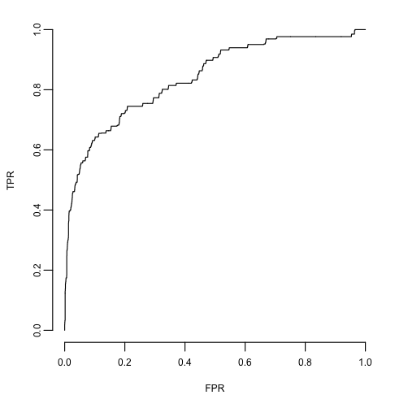

```r
r <- survivalROC(Stime = s[,1], status=s[,2], marker=fitAll$linear.predictors[w]-colMeans(fitAll$Z[w,]) %*% fitAll$coefficients, predict.time = 10, method="NNE", span=0.001)
plot(r$FP, r$TP, type='s', xlab="FPR", ylab="TPR")
```

```r
round(r$AUC, 3)
```

```
## [1] 0.84
```

### 7.4.2 Adjusted

```r
fitWeighted <- CoxRFX(allX, allSurv, allGroups, which.mu=which.mu, sigma0=sigma0, nu=nu, weights=weights)
waldWeighted <- WaldTest(fitWeighted)
```

```
##                   group    coef coef-mu     sd      z df  p.value sig
## ASXL1_0.1         Genes  1.9907  0.0666 0.1328 14.985  1 9.18e-51 ***
## BCOR_0.1          Genes  2.1375  0.2134 0.1144 18.677  1 7.57e-78 ***
## CBL_0.1           Genes  0.3984 -1.5256 0.3634  1.096  1 2.73e-01
## DNMT3A_0.1        Genes  0.6589 -1.2652 0.1112  5.926  1 3.10e-09 ***
## IDH1_0.1          Genes  2.4306  0.5065 0.3313  7.337  1 2.18e-13 ***
## IDH2_0.1          Genes  0.8422 -1.0818 0.2181  3.862  1 1.13e-04 ***
## JAK2_0.1          Genes  1.8770 -0.0471 0.1954  9.607  1 7.44e-22 ***
## KDM6A_0.1         Genes  1.9370  0.0129 0.1241 15.607  1 6.51e-55 ***
## KMT2C_0.1         Genes  2.3674  0.4434 0.7114  3.328  1 8.75e-04 ***
## KMT2D_0.1         Genes  0.1632 -1.7609 0.4835  0.338  1 7.36e-01
## KRAS_0.1          Genes  1.9831  0.0590 0.1706 11.622  1 3.20e-31 ***
## NF1_0.1           Genes  1.5839 -0.3402 0.4410  3.592  1 3.29e-04 ***
## NRAS_0.1          Genes  2.3167  0.3926 0.1248 18.569  1 5.76e-77 ***
## PHF6_0.1          Genes  2.2266  0.3025 0.1241 17.937  1 6.04e-72 ***
## PTPN11_0.1        Genes  2.1631  0.2390 0.3107  6.962  1 3.35e-12 ***
## RAD21_0.1         Genes  1.8365 -0.0876 0.2512  7.311  1 2.65e-13 ***
## RUNX1_0.1         Genes  0.8106 -1.1134 0.1329  6.098  1 1.08e-09 ***
## SF3B1_0.1         Genes  3.1070  1.1829 0.3114  9.977  1 1.92e-23 ***
## SRSF2_0.1         Genes  1.3684 -0.5557 0.1491  9.176  1 4.47e-20 ***
## TET2_0.1          Genes  0.9527 -0.9714 0.1172  8.126  1 4.45e-16 ***
## TP53_0.1          Genes  5.0534  3.1293 0.3907 12.934  1 2.88e-38 ***
## U2AF1_0.1         Genes  4.1247  2.2006 0.3300 12.498  1 7.67e-36 ***
## age_10     Demographics -0.0962 -0.0962 0.0863 -1.114  1 2.65e-01
## gender     Demographics -0.0522 -0.0522 0.1044 -0.499  1 6.17e-01
## cohort     Demographics  0.0499  0.0499 0.0973  0.512  1 6.08e-01
```

```r
survConcordance(fitWeighted$surv ~ fitWeighted$linear.predictor, weights=weights)
```

```
## Call:
## survConcordance(formula = fitWeighted$surv ~ fitWeighted$linear.predictor,
##     weights = weights)
##
##   n= 950
## Concordance= 0.7778849 se= 0.02802535
##   concordant   discordant    tied.risk    tied.time     std(c-d)
## 6313552.2348 1802641.1313     317.7601       1.0000  454936.0746
```

Dynamic/cumulative AUC

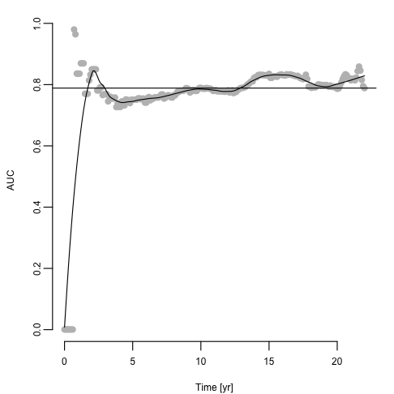

```r
w <- c(which(allSurv[,1]==0)[-1]-1, nrow(allSurv))
survAll2 <- Surv(allSurv[w,2], allSurv[w,3])
t <- seq(0,22,0.1)
a <- AUC.uno(survAll2, survAll2, fitWeighted$linear.predictor[w], times=t)
plot(a$times, a$auc, xlab="Time [yr]", ylab="AUC", pch=16, col='grey')
lines(a$times, predict(loess(a$auc ~ a$times, span=0.25)))
abline(h=a$iauc)
```

```r
round(a$iauc, 3)
```

```
## [1] 0.789
```

```r
png("./figures/combined.ajd.coxph.auc.uno.png", width = 9, height = 10, units = "cm", res = 500)
par(mar = c(3.2, 3.2, 4, 2) + 0.1, mgp=c(2,0.5,0), bty="L",  tcl =-0.2, las = 1, cex=1)
plot(a$times, a$auc, xlab="Time (years)", ylab="AUC", pch=16, col="grey80", ylim = c(0,1.0))
lines(a$times, predict(loess(a$auc ~ a$times, span=0.25)))
abline(h=a$iauc, lty = 3, lwd = 1)
#mtext("Combined adjusted Cox PH", font= 2, side = 3, line = 0.5)
legend("bottomright", bty = "n", legend = paste("AUC = ",round(a$iauc,2)))
dev.off()
```

Time-depenent ROC

```r
r <- survivalROC(Stime = survAll2[,1], status=survAll2[,2], marker=fitWeighted$linear.predictors[w]-colMeans(fitWeighted$Z[w,]) %*% fitWeighted$coefficients, predict.time = 10, method="NNE", span=0.001)
round(r$AUC, 3)
```

```
## [1] 0.791
```

```r
png("./figures/Combined.adj.coxph.roct.png", width = 9, height = 10, units = "cm", res = 500)
par(mar = c(3.2, 3.2, 4, 2) + 0.1, mgp=c(2,0.5,0), bty="L",  tcl =-0.2, las = 1, cex = 1)
plot(r$FP, r$TP, type='s',
     xlab="False Positive Rate", ylab="True Positive Rate",
     col = "black")
abline(a = 0, b = 1, col = "grey70", lty = 1, lwd = 1)
legend("bottomright", bty = "n", legend = paste("AUC = ",round(r$AUC,2)))
dev.off()
```

### 7.4.3 Bootstrap

```r
coefWeightedBoot <- sapply(1:100, function(foo){
            set.seed(foo)
            b <- unique(sample(1:nrow(allX), replace=TRUE))
            fitWeighted <- CoxRFX(allX[b,], allSurv[b,], allGroups, which.mu=which.mu, sigma0=sigma0, nu=5, weights=weights[b])
            c(coef(fitWeighted), 'mu.Genes'=fitWeighted$mu["Genes"])
        })
```

```r
concBoots <- sapply(1:100, function(foo){
            set.seed(foo)
            b <- unique(sample(1:nrow(allX), replace=TRUE))
            oob <- !1:nrow(allX) %in% b
            c(inb=as.numeric(survConcordance(allSurv[b,]~ as.matrix(allX)[b,] %*% coefWeightedBoot[-26,foo], weights=weights[b])$concordance),
                    oob=as.numeric(survConcordance(allSurv[oob,]~ as.matrix(allX)[oob,] %*% coefWeightedBoot[-26,foo],weights=weights[oob])$concordance),
                    auc = AUC.uno(survAll2[oob[w],], survAll2[oob[w],], as.matrix(allX)[w,][oob[w],] %*% coefWeightedBoot[-26,foo], times=t)$iauc
            )
        })

apply(concBoots,1,quantile)
```

```
##            inb       oob       auc
## 0%   0.7127155 0.6414249 0.6163769
## 25%  0.7623231 0.7268340 0.7333587
## 50%  0.7757864 0.7643297 0.7833229
## 75%  0.7985773 0.7875492 0.8223659
## 100% 0.8519811 0.8713292 0.8805585
```

### 7.4.4 Forest plot

Figure 3

```r
pal1 <- c("#C32B4A", "#3F76B4", "#57B2AB", "#5E4FA2", "#EB6046")
rownames(waldWeighted)
```

```
##  [1] "ASXL1_0.1"  "BCOR_0.1"   "CBL_0.1"    "DNMT3A_0.1" "IDH1_0.1"   "IDH2_0.1"   "JAK2_0.1"   "KDM6A_0.1"
##  [9] "KMT2C_0.1"  "KMT2D_0.1"  "KRAS_0.1"   "NF1_0.1"    "NRAS_0.1"   "PHF6_0.1"   "PTPN11_0.1" "RAD21_0.1"
## [17] "RUNX1_0.1"  "SF3B1_0.1"  "SRSF2_0.1"  "TET2_0.1"   "TP53_0.1"   "U2AF1_0.1"  "age_10"     "gender"
## [25] "cohort"
```

```r
png("./figures/Combined.adj.coxph.boostrapped.forest.png", width = 15.5, height = 17, units = "cm", res = 800)
par(bty="n", mar=c(3,6,3,15)+.5, mgp=c(2,0.5,0), xpd=FALSE, tcl=-.25, cex = 0.9)
c <- c(waldWeighted[-25,"coef"], "mu"=fitWeighted$mu["Genes"]); names(c)[1:24] <- rownames(waldWeighted)[-25] #-25 removes 'cohort' variable
o <- c(23:24,1:22,25)
s <- c(rep(1,2), rep(.5, 23))
c <- exp(c*c(rep(0.5,22), c(1,1),0.5))
ci <- apply(coefWeightedBoot,1,quantile, c(0.025,0.975))[,-25] * rep(c(rep(0.5,22), c(1,1),0.5), each=2)
y <- rev(seq_along(c))
plot(c[o], y, xlab="Hazard ratio", log='x', ylab='', xaxt = "n", yaxt="n", pch=NA, xlim=c(0.5,50))
atx <- axTicks(1)
axis(1,at=atx,labels=atx)
segments(x0=0.5, x1 = 50, y0=y, y1=y, col="#EEEEEE", lty=1)
abline(v=1, lty=1, col="grey")
abline(v=c["mu.Genes"], col=mg14::colTrans("#57B2AB"), lty=1)
segments(exp(ci[1,o]), y, exp(ci[2,o]),y)
points(c[o], y, xlab="",  bg=pal1[3], cex=2, pch=c(rep(21,24), 23))
m1 <- match(names(c)[o],rownames(waldWeightedToronto))[-25]
points(exp(c(waldWeightedToronto$coef[m1], fitWeightedToronto$mu["Genes"])*s), y,bg=pal1[4], pch=c(rep(21,24), 23), cex=1)
m2 <- match(names(c)[o],rownames(waldWeightedSanger))[-25]
points(exp(c(waldWeightedSanger$coef[m2], fitWeightedSanger$mu["Genes"])*s), y,bg=pal1[5], pch=c(rep(21,24), 23), cex=1)
mtext(side=2, sub("mu.Genes","Av. gene", sub("_.+","", sub("age", "Age", sub("gender", "Gender", names(c)[o])))), at=y, las=2, cex=0.85, font=c(1,1,rep(3,22),1))
r <- sapply(split(as.data.frame(allX>0), control), colMeans)
f <- sapply(split(allX, control), apply, 2, function(x) mean(x[x>0]))
par(xpd=NA)
points(rep(100,22),y[3:24], cex=sqrt(r[o[3:24],2]*10), pch=21, bg=pal1[2])
points(rep(100*1.5,22), y[3:24], cex=sqrt(r[o[3:24],1]*10), pch=21, bg=pal1[1])
points(rep(360,22),y[3:24], cex=sqrt(f[o[3:24],2]), pch=21, bg=set1[2])
points(rep(360*1.5,22), y[3:24], cex=sqrt(f[o[3:24],1]), pch=21, bg=pal1[1])
legend(x=0.8, y=27.8, pch=21, pt.bg=pal1[c(4,5,3)], c("DC","VC","Combined"), bty="n", ncol=3, text.width=0.25)
text(y=24, x=100, "     Frequency", cex = 0.92)
text(y=24, x=360*1.5, "VAF    ", cex = 0.92)
axis(1, at=c(100,100*1.5), c("Control ","Pre-AML "), las=2, line=-1, cex = 0.89)
axis(1, at=c(360,360*1.5), c("Control ","Pre-AML "), las=2, line=-1, cex = 0.89)
dev.off()
```

```r
Fig3Data1 <- data.frame(Parameter = sapply(strsplit(names(c[o]), "_"), "[", 1),
                        CombinedModel.HR = round(c[o], 1),
                        CombinedModel.HR.CI2.5 = round(exp(ci[1,o]), 1),
                        CombinedModel.HR.CI97.5 = round(exp(ci[2,o]),1),
                        DC.HR = round(exp(c(waldWeightedToronto$coef[m1], fitWeightedToronto$mu["Genes"])*s),1),
                        VC.HR = round(exp(c(waldWeightedSanger$coef[m2], fitWeightedSanger$mu["Genes"])*s),1)
                        )
rownames(Fig3Data1) <- NULL
head(Fig3Data1)
```

|  | Parameter | CombinedModel.HR | CombinedModel.HR.CI2.5 | CombinedModel.HR.CI97.5 | DC.HR | VC.HR |
| --- | --- | --- | --- | --- | --- | --- |
| 1 | age | 0.9 | 0.8 | 1.0 | 0.9 | 1.0 |
| 2 | gender | 0.9 | 0.8 | 1.2 | 1.0 | 1.0 |
| 3 | ASXL1 | 2.7 | 2.5 | 6.6 | 2.6 | 4.3 |
| 4 | BCOR | 2.9 | 2.5 | 11.1 | NA | NA |
| 5 | CBL | 1.2 | 1.0 | 5.1 | 1.2 | 1.6 |
| 6 | DNMT3A | 1.4 | 1.2 | 1.8 | 1.4 | 1.5 |

```r
table(rownames(r)==rownames(f))
```

```
##
## TRUE
##   25
```

```r
Fig3Data2 <- data.frame(Parameter = sapply(strsplit(rownames(r), "_"), "[", 1)[1:22],
                        Frequency_PreAML = round(r[1:22, 1],3),
                        Frequency_Controls = round(r[1:22, 2],3),
                        MeanVAF_PreAML = round(f[1:22, 1],3),
                        MeanVAF_Control = round(f[1:22, 2],3))
head(Fig3Data2)
```

|  | Parameter | Frequency_PreAML | Frequency_Controls | MeanVAF_PreAML | MeanVAF_Control |
| --- | --- | --- | --- | --- | --- |
| ASXL1_0.1 | ASXL1 | 0.090 | 0.021 | 1.262 | 0.127 |
| BCOR_0.1 | BCOR | 0.008 | 0.001 | 0.117 | 0.069 |
| CBL_0.1 | CBL | 0.030 | 0.011 | 0.414 | 0.716 |
| DNMT3A_0.1 | DNMT3A | 0.391 | 0.212 | 0.950 | 0.337 |
| IDH1_0.1 | IDH1 | 0.023 | 0.001 | 1.156 | 0.115 |
| IDH2_0.1 | IDH2 | 0.038 | 0.001 | 1.848 | 0.109 |

```r
rownames(Fig3Data2) <- NULL
Fig3Data <- left_join(x = Fig3Data1, y = Fig3Data2, by = 'Parameter')
Fig3Data$Parameter <- ifelse(Fig3Data$Parameter == "mu.Genes", "Av.gene", Fig3Data$Parameter)
#View(Fig3Data)
write_csv(Fig3Data, "./figures/Figure3_Data.csv")
```

### 7.4.5 Dichotomous variables

```r
allXDich <- allX
allXDich[allGroups=="Genes"] <- (allXDich[allGroups=="Genes"] > 0) + 0
fitWeightedDich <- CoxRFX(allXDich, allSurv, allGroups, which.mu=which.mu, sigma0=sigma0, nu=nu, weights=weights)

WaldTest(fitWeightedDich)
```

```
##                   group    coef coef-mu     sd       z df  p.value sig
## ASXL1_0.1         Genes  1.3797 -0.3942 0.3175  4.3456  1 1.39e-05 ***
## BCOR_0.1          Genes  2.5308  0.7570 0.8406  3.0106  1 2.61e-03  **
## CBL_0.1           Genes  0.3932 -1.3806 0.4991  0.7879  1 4.31e-01
## DNMT3A_0.1        Genes  0.7794 -0.9944 0.2049  3.8048  1 1.42e-04 ***
## IDH1_0.1          Genes  2.0403  0.2665 0.5817  3.5073  1 4.53e-04 ***
## IDH2_0.1          Genes  3.9907  2.2169 0.5363  7.4414  1 9.96e-14 ***
## JAK2_0.1          Genes  3.2315  1.4577 0.3911  8.2629  1 1.42e-16 ***
## KDM6A_0.1         Genes  0.7396 -1.0343 0.7822  0.9456  1 3.44e-01
## KMT2C_0.1         Genes -0.4630 -2.2368 0.5910 -0.7834  1 4.33e-01
## KMT2D_0.1         Genes  0.8142 -0.9597 0.9409  0.8653  1 3.87e-01
## KRAS_0.1          Genes -0.0209 -1.7948 0.7030 -0.0298  1 9.76e-01
## NF1_0.1           Genes -1.1385 -2.9124 0.8236 -1.3824  1 1.67e-01
## NRAS_0.1          Genes  1.6320 -0.1419 0.7812  2.0891  1 3.67e-02   *
## PHF6_0.1          Genes  4.0915  2.3176 0.7069  5.7883  1 7.11e-09 ***
## PTPN11_0.1        Genes  2.2597  0.4859 0.6548  3.4510  1 5.59e-04 ***
## RAD21_0.1         Genes  1.0923 -0.6816 0.9283  1.1767  1 2.39e-01
## RUNX1_0.1         Genes  2.6557  0.8818 0.5738  4.6284  1 3.69e-06 ***
## SF3B1_0.1         Genes  0.0815 -1.6924 0.6027  0.1352  1 8.92e-01
## SRSF2_0.1         Genes  4.2431  2.4693 0.3084 13.7566  1 4.65e-43 ***
## TET2_0.1          Genes  0.9715 -0.8023 0.2351  4.1328  1 3.58e-05 ***
## TP53_0.1          Genes  2.0033  0.2295 0.4168  4.8067  1 1.53e-06 ***
## U2AF1_0.1         Genes  5.7172  3.9433 0.4178 13.6831  1 1.28e-42 ***
## age_10     Demographics -0.3024 -0.3024 0.0958 -3.1571  1 1.59e-03  **
## gender     Demographics -0.0512 -0.0512 0.1362 -0.3759  1 7.07e-01
## cohort     Demographics  0.2569  0.2569 0.1435  1.7896  1 7.35e-02   .
```

```r
survConcordance(allSurv ~ fitWeightedDich$linear.predictors, weights=weights)
```

```
## Call:
## survConcordance(formula = allSurv ~ fitWeightedDich$linear.predictors,
##     weights = weights)
##
##   n= 950
## Concordance= 0.764251 se= 0.02802535
##   concordant   discordant    tied.risk    tied.time     std(c-d)
## 6202805.3608 1913213.1798     492.5856       1.0000  454936.0734
```

### 7.4.6 Bootstrap adjustment

To compare to the weighted CoxRFX models

```r
set.seed(42)

p <- c(rep(n_total_sanger, sum(cohort=="Sanger" & control)), rep(n_total_toronto, sum(cohort=="Toronto" & control)))
b42 <- c(sample(which(control), size=round(n_total) - sum(!control), prob=p, replace=TRUE), which(!control))

fitBoot <- CoxRFX(allX[b42,], allSurv[b42,], allGroups, which.mu=which.mu, sigma0=sigma0, nu=nu)

set.seed(42)
b <- c(sample(which( sangerData$Diagnosis=="Control"), size=round(n_total_sanger) - sum(sangerData$Diagnosis!="Control"), replace=TRUE), which(sangerData$Diagnosis!="Control"))

fitBootSanger <- CoxRFX(sangerX[b,], sangerSurv[b,], sangerGroups, which.mu=which.mu, sigma0=sigma0, nu=nu)

survConcordance(fitBootSanger$surv ~ fitBootSanger$linear.predictors)
```

```
## Call:
## survConcordance(formula = fitBootSanger$surv ~ fitBootSanger$linear.predictors)
##
##   n= 10407
## Concordance= 0.8334695 se= 0.05475909
## concordant discordant  tied.risk  tied.time   std(c-d)
##   140833.0    28139.0        0.0        0.0    18505.5
```

```r
waldBootSanger <- WaldTest(fitBootSanger)
```

```
##                    group     coef  coef-mu      sd       z df  p.value sig
## ASXL1_0.1          Genes  2.75130  0.85036 0.44987  6.1157  1 9.61e-10 ***
## CBL_0.1            Genes  0.90179 -0.99914 1.17452  0.7678  1 4.43e-01
## DNMT3A_0.1         Genes  0.75840 -1.14254 0.22408  3.3845  1 7.13e-04 ***
## JAK2_0.1           Genes -0.20568 -2.10662 0.92220 -0.2230  1 8.24e-01
## KMT2C_0.1          Genes  2.16912  0.26819 0.96833  2.2401  1 2.51e-02   *
## KMT2D_0.1          Genes  0.06618 -1.83475 0.76576  0.0864  1 9.31e-01
## KRAS_0.1           Genes  2.31066  0.40972 0.38106  6.0638  1 1.33e-09 ***
## NF1_0.1            Genes  1.57512 -0.32581 0.77819  2.0241  1 4.30e-02   *
## NRAS_0.1           Genes  1.84937 -0.05157 0.35761  5.1715  1 2.32e-07 ***
## RAD21_0.1          Genes  1.70593 -0.19501 0.58727  2.9049  1 3.67e-03  **
## SF3B1_0.1          Genes  1.54550 -0.35544 0.87032  1.7758  1 7.58e-02   .
## SRSF2_0.1          Genes  1.40565 -0.49529 0.27962  5.0271  1 4.98e-07 ***
## TET2_0.1           Genes  1.25279 -0.64815 0.13571  9.2317  1 2.66e-20 ***
## TP53_0.1           Genes  4.63845  2.73751 0.89272  5.1959  1 2.04e-07 ***
## U2AF1_0.1          Genes  5.78946  3.88853 0.73724  7.8528  1 4.07e-15 ***
## age_10      Demographics  0.04278  0.04278 0.11873  0.3603  1 7.19e-01
## gender      Demographics -0.01852 -0.01852 0.10088 -0.1836  1 8.54e-01
## systol_100         Blood  0.02344  0.02344 0.04556  0.5145  1 6.07e-01
## diastol_100        Blood  0.04133  0.04133 0.03020  1.3686  1 1.71e-01
## bmi_10             Blood  0.14916  0.14916 0.08426  1.7702  1 7.67e-02   .
## cholestl_10        Blood  0.00303  0.00303 0.01547  0.1958  1 8.45e-01
## triglyc            Blood -0.02770 -0.02770 0.11803 -0.2347  1 8.14e-01
## hdl                Blood -0.12117 -0.12117 0.08479 -1.4291  1 1.53e-01
## ldl                Blood  0.13479  0.13479 0.11448  1.1775  1 2.39e-01
## lym                Blood  0.08408  0.08408 0.10435  0.8057  1 4.20e-01
## mcv_100            Blood -0.02485 -0.02485 0.00798 -3.1160  1 1.83e-03  **
## rdw_10             Blood  0.06629  0.06629 0.01703  3.8934  1 9.88e-05 ***
## wbc_10             Blood  0.01199  0.01199 0.04735  0.2532  1 8.00e-01
## plt_100            Blood  0.09163  0.09163 0.10006  0.9158  1 3.60e-01
## hgb_10             Blood  0.03986  0.03986 0.02497  1.5960  1 1.10e-01
```

```r
set.seed(42)
b <- c(sample(which( torontoData$Diagnosis=="Control"), size=round(n_total_toronto) - sum(torontoData$Diagnosis!="Control"), replace=TRUE), which(torontoData$Diagnosis!="Control"))

fitBootToronto <- CoxRFX(torontoX[b,], torontoSurv[b,], torontoGroups, which.mu=which.mu, sigma0=sigma0, nu=nu)
survConcordance(fitBootToronto$surv ~ fitBootToronto$linear.predictors)
```

```
## Call:
## survConcordance(formula = fitBootToronto$surv ~ fitBootToronto$linear.predictors)
##
##   n= 72378
## Concordance= 0.7750173 se= 0.03055346
## concordant discordant  tied.risk  tied.time   std(c-d)
##  4722585.0  1370937.0        0.0        1.0   372356.4
```

```r
waldWeightedToronto <- WaldTest(fitBootToronto)
```

```
##                   group    coef  coef-mu     sd      z df  p.value sig
## ASXL1_0.1         Genes  1.9494  0.01801 0.1451 13.430  1 4.03e-41 ***
## CALR_0.1          Genes  0.9415 -0.98990 0.7233  1.302  1 1.93e-01
## CBL_0.1           Genes  0.3663 -1.56509 0.3604  1.016  1 3.09e-01
## DNMT3A_0.1        Genes  0.7358 -1.19559 0.1243  5.921  1 3.20e-09 ***
## IDH1_0.1          Genes  2.3973  0.46594 0.3355  7.145  1 8.98e-13 ***
## IDH2_0.1          Genes  0.8078 -1.12360 0.2283  3.538  1 4.03e-04 ***
## JAK2_0.1          Genes  1.9240 -0.00738 0.1822 10.562  1 4.49e-26 ***
## KDM6A_0.1         Genes  1.9436  0.01219 0.1340 14.506  1 1.12e-47 ***
## KMT2C_0.1         Genes  2.4194  0.48806 0.6410  3.774  1 1.60e-04 ***
## KRAS_0.1          Genes  1.8282 -0.10316 0.1559 11.725  1 9.46e-32 ***
## NF1_0.1           Genes  1.8677 -0.06366 0.1512 12.353  1 4.69e-35 ***
## PHF6_0.1          Genes  2.1755  0.24415 0.1302 16.711  1 1.08e-62 ***
## PTPN11_0.1        Genes  2.5369  0.60555 0.2217 11.445  1 2.49e-30 ***
## RUNX1_0.1         Genes  0.7795 -1.15181 0.1359  5.738  1 9.57e-09 ***
## SF3B1_0.1         Genes  3.1337  1.20231 0.3091 10.138  1 3.76e-24 ***
## SRSF2_0.1         Genes  1.4023 -0.52910 0.1703  8.235  1 1.80e-16 ***
## TET2_0.1          Genes  0.6503 -1.28104 0.2012  3.232  1 1.23e-03  **
## TP53_0.1          Genes  4.8664  2.93502 0.4220 11.532  1 9.14e-31 ***
## U2AF1_0.1         Genes  3.9705  2.03910 0.3601 11.025  1 2.89e-28 ***
## age_10     Demographics -0.0891 -0.08907 0.0998 -0.892  1 3.72e-01
## gender     Demographics -0.0449 -0.04493 0.1114 -0.403  1 6.87e-01
```

Compare results

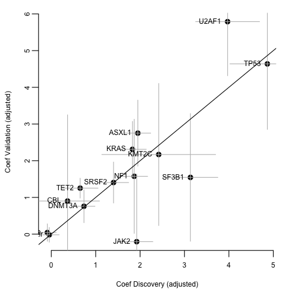

```r
i <- intersect(rownames(waldBootSanger), rownames(waldWeightedToronto))
plot( waldWeightedToronto[i,"coef"], waldBootSanger[i, "coef"], xlab="Coef Discovery (adjusted)", ylab="Coef Validation (adjusted)", pch=19, cex=1)#sqrt(colMeans(rbind(sangerX[,i], torontoX[,i])>0)*100))
segments(waldWeightedToronto[i,"coef"]  - 2*waldWeightedToronto[i,"sd"], waldBootSanger[i, "coef"], waldWeightedToronto[i,"coef"]  + 2*waldWeightedToronto[i,"sd"], waldBootSanger[i, "coef"], col="grey" )
segments(waldWeightedToronto[i,"coef"]  , waldBootSanger[i, "coef"]-  2*waldBootSanger[i,"sd"], waldWeightedToronto[i,"coef"] , waldBootSanger[i, "coef"] +2*waldBootSanger[i,"sd"], col="grey")
text(labels=sub("_.+","", i), waldWeightedToronto[i,"coef"], waldBootSanger[i, "coef"], pos=2, adj=c(0,1))
abline(0,1)
```

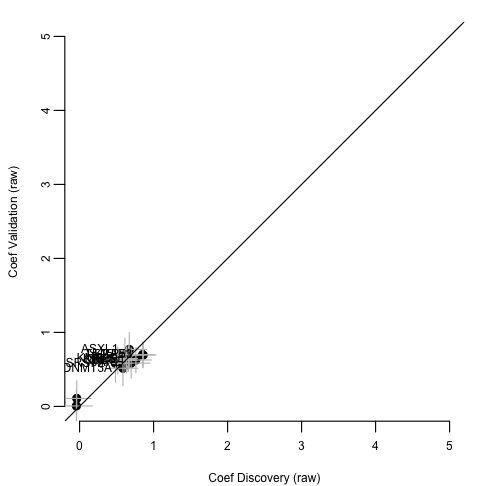

```r
plot( waldToronto[i,"coef"], waldSanger[i, "coef"], xlab="Coef Discovery (raw)", ylab="Coef Validation (raw)", pch=19, cex=1, ylim=c(0,5),xlim=c(0,5))#sqrt(colMeans(rbind(sangerX[,i], torontoX[,i])>0)*100))
segments(waldToronto[i,"coef"]  - 2*waldToronto[i,"sd"], waldSanger[i, "coef"], waldToronto[i,"coef"]  + 2*waldToronto[i,"sd"], waldSanger[i, "coef"], col="grey" )
segments(waldToronto[i,"coef"]  , waldSanger[i, "coef"]-  2*waldSanger[i,"sd"], waldToronto[i,"coef"] , waldSanger[i, "coef"] +2*waldSanger[i,"sd"], col="grey")
text(labels=sub("_.+","", i), waldToronto[i,"coef"], waldSanger[i, "coef"], pos=2, adj=c(0,1))
abline(0,1)
```

### 7.4.7 LOOCV

```r
samples <- factor(c(as.character(sangerData$Individual), as.character(torontoData$Sample)))
```

```r
looAll <- do.call("rbind",mclapply(levels(samples), function(l){
                    i <- samples!=l
                    f <<- CoxRFX(allX[i,], allSurv[i,], allGroups, which.mu=which.mu, sigma0=sigma0, nu=nu)
                    p <- as.matrix(allX[!i,,drop=FALSE]) %*% f$coefficients
                    r <- cbind(matrix(f$coefficients, nrow=length(p), ncol=length(f$coefficients), byrow=TRUE), linear.predictor=p)
                    colnames(r) <- c(names(f$coefficients), "linear.predictor")
                    as.data.frame(r)
                }, mc.cores=4))
looAll <- looAll[order(order(samples)),]
pp <- looAll$linear.predictor

c <- rbind(
        `Toronto (fit)`=as.data.frame(survConcordance(torontoSurv ~ fitToronto$linear.predictors)[c("concordance","std.err")]),
        `Toronto (val)`=as.data.frame(survConcordance(sangerSurv ~ pS[,1])[c("concordance","std.err")]),
        `Sanger (fit)`=as.data.frame(survConcordance(sangerSurv ~ fitSanger$linear.predictors)[c("concordance","std.err")]),
        `Sanger (val)`=as.data.frame(survConcordance(torontoSurv ~ pT[,1])[c("concordance","std.err")]),
        `Combined (fit)`=as.data.frame(survConcordance(allSurv ~ fitAll$linear.predictors)[c("concordance","std.err")]),
        `Combined (val)`=as.data.frame(survConcordance(allSurv ~ pp)[c("concordance","std.err")]))

c
```

|  | concordance | std.err |
| --- | --- | --- |
| Toronto (fit) | 0.7426378 | 0.03079247 |
| Toronto (val) | 0.8069747 | 0.05514445 |
| Sanger (fit) | 0.7939150 | 0.05514512 |
| Sanger (val) | 0.7000180 | 0.03079247 |
| Combined (fit) | 0.8059859 | 0.02746324 |
| Combined (val) | 0.7847548 | 0.02746328 |

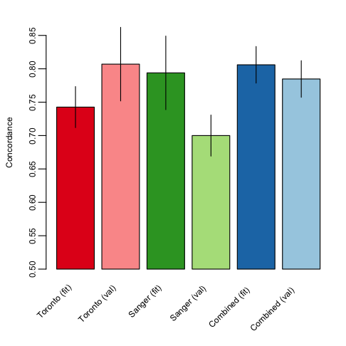

```r
par(mar=c(5,3,1,1), mgp=c(2,.5,0))
b <- barplot(c$concordance-0.5, ylab="Concordance", col=rev(RColorBrewer::brewer.pal(6,"Paired")), ylim=c(0.5,0.88), offset=0.5)
mg14::rotatedLabel(x=b, labels=rownames(c))
segments(b,c$concordance+c$std.err,b,c$concordance-c$std.err)
```

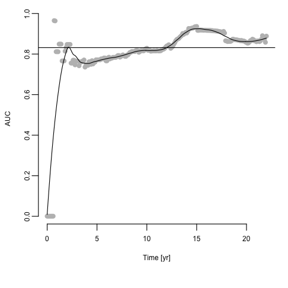

```r
w <- c(which(allSurv[,1]==0)[-1]-1, nrow(allSurv))
survAll2 <- Surv(allSurv[w,2], allSurv[w,3])
t <- seq(0,22,0.1)
a <- AUC.uno(survAll2, survAll2, looAll$linear.predictor[w], times=t)
plot(a$times, a$auc, xlab="Time [yr]", ylab="AUC", pch=16, col='grey')
lines(a$times, predict(loess(a$auc ~ a$times, span=0.25)))
abline(h=a$iauc)
```

```r
round(a$iauc, 3)
```

```
## [1] 0.832
```

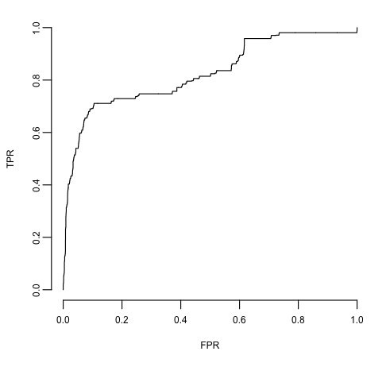

```r
r <- survivalROC(Stime = survAll2[,1], status=survAll2[,2], marker=looAll$linear.predictor[w], predict.time = 10, method="NNE", span=0.001)#0.25*nrow(s)^(-0.20))
plot(r$FP, r$TP, type='s', xlab="FPR", ylab="TPR")
```

```r
round(r$AUC, 3)
```

```
## [1] 0.825
```

#### 7.4.7.1 Individual Predictions (non-adjusted)

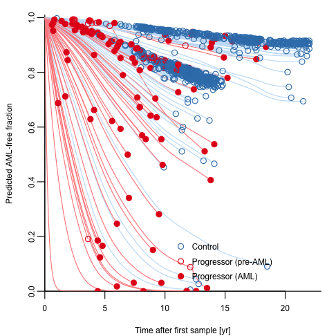

```r
plot(survfit(allSurv~1), conf.int=FALSE, xlab='Time after first sample [yr]', ylab='Predicted AML-free fraction', col='white', bty='L', yaxs='i', ylim=c(0,1.01))
d <- data.frame(t=NULL, s=NULL, pch=NULL, col=character())
for(i in unique(samples)){
    km <- exp(predict(smooth.spline(log(summary(survfit(allSurv[samples!=i,]~1), times=t)$surv), df=10))$y)
    l0 <- colMeans(fitAll$Z[samples!=i,,drop=FALSE]) %*% as.numeric(looAll[samples==i,][1,colnames(fitAll$Z)])
    kmi <- function(km, s, lp, l0){
        .kmi <- function(km, sj, lpj, l0) km[t >= sj[,1] & t <= sj[,2]]^exp(lpj-l0)
        k0 <- 1
        for(j in 1:nrow(s)) {
            k <- .kmi(km, s[j,], lp[j], l0)
            k <- k * k0/k[1]
            w <- t >= s[j,1] & t <= s[j,2]
            k0 <- k[length(k)]
            c <- if(s[nrow(s),3]==1) set1[1] else set1[2]
            #if(c==set1[1]) next
            lines(t[w], k, col=mg14:::colTrans(c), type='l')
            p <- if(s[j,3]==1) 19 else 1
            #points(t[w][length(k)], k[length(k)], col=c, pch=p)
            d <<- rbind(d, data.frame(t=t[w][length(k)], s=k[length(k)], pch=p, col=c))
        }
    }
    kmi(km, allSurv[samples==i,], looAll$linear.predictor[samples==i], l0)
}
points(d$t, d$s, pch=d$pch, col=as.character(d$col))
legend("bottomright", pch=c(1,1,19), col=c(set1[2], set1[1], set1[1]), legend=c("Control", "Progressor (pre-AML)", "Progressor (AML)"), bty='n')
```

#### 7.4.7.2 Jackknife variance

```r
i <- !duplicated(samples)
coef.jack <- colMeans(looAll[i,-ncol(looAll)])
var.jack <- rowSums((t(looAll[i,-ncol(looAll)]) - coef.jack)^2) * (sum(i)-1)/sum(i)

p.jack <- pchisq(coef.jack^2/var.jack,1, lower.tail=FALSE)

data.frame(coef.jack, p.jack, sig=mg14::sig2star(p.jack), n=colSums(allX[i,]>0))
```

|  | coef.jack | p.jack | sig | n |
| --- | --- | --- | --- | --- |
| ASXL1_0.1 | 0.74835623 | 1.277998e-05 | *** | 26 |
| BCOR_0.1 | 0.80859507 | 2.311062e-04 | *** | 1 |
| CBL_0.1 | 0.47795378 | 3.123703e-01 |  | 12 |
| DNMT3A_0.1 | 0.55685260 | 7.358773e-06 | *** | 194 |
| IDH1_0.1 | 0.81211760 | 5.586147e-10 | *** | 3 |
| IDH2_0.1 | 0.51251777 | 1.351015e-01 |  | 6 |
| JAK2_0.1 | 0.75979214 | 3.181470e-08 | *** | 10 |
| KDM6A_0.1 | 0.79059980 | 7.666406e-05 | *** | 3 |
| KMT2C_0.1 | 0.85878619 | 5.304616e-04 | *** | 6 |
| KMT2D_0.1 | 0.40005469 | 3.584861e-01 |  | 1 |

[output cut: 15 more lines]

### 7.4.8 Multiple bootstraps

```r
save(file="boot.RData", control, allX, allSurv, sigma0, nu, which.mu, allGroups, n_total, cohort, p)
```

```r
fitBoots <- simplify2array(mclapply(1:100, function(foo){
                    set.seed(foo)
                    w <- which(control)
                    s <- sample(seq_along(which(control)), replace=TRUE)
                    b <- c(sample(which(control)[s], size=round(n_total) - sum(!control), prob=p[s], replace=TRUE), sample(which(!control), replace=TRUE))
                    fitBoot <- CoxRFX(allX[b,], allSurv[b,], allGroups, which.mu=which.mu, sigma0=sigma0, nu=nu)
                    fitBoot$coefficients
                }, mc.cores=4))
save(fitBoots, file="fitBoots.RData")
```

```r
load('fitBoots.RData')

WaldTest(fitBoot)
```

```
##                   group    coef coef-mu     sd      z df  p.value sig
## ASXL1_0.1         Genes  1.9782  0.0682 0.1330 14.873  1 4.90e-50 ***
## BCOR_0.1          Genes  2.1204  0.2104 0.1157 18.319  1 5.81e-75 ***
## CBL_0.1           Genes  0.3747 -1.5352 0.3614  1.037  1 3.00e-01
## DNMT3A_0.1        Genes  0.6499 -1.2600 0.1133  5.735  1 9.77e-09 ***
## IDH1_0.1          Genes  2.4215  0.5116 0.3299  7.341  1 2.12e-13 ***
## IDH2_0.1          Genes  0.8614 -1.0486 0.2191  3.931  1 8.47e-05 ***
## JAK2_0.1          Genes  1.8708 -0.0391 0.1956  9.562  1 1.15e-21 ***
## KDM6A_0.1         Genes  1.9211  0.0112 0.1251 15.363  1 2.92e-53 ***
## KMT2C_0.1         Genes  2.3935  0.4836 0.7067  3.387  1 7.07e-04 ***
## KMT2D_0.1         Genes  0.1309 -1.7790 0.4810  0.272  1 7.86e-01
## KRAS_0.1          Genes  1.9602  0.0503 0.1717 11.415  1 3.53e-30 ***
## NF1_0.1           Genes  1.5704 -0.3396 0.4386  3.580  1 3.43e-04 ***
## NRAS_0.1          Genes  2.3060  0.3960 0.1213 19.014  1 1.31e-80 ***
## PHF6_0.1          Genes  2.2127  0.3028 0.1241 17.835  1 3.80e-71 ***
## PTPN11_0.1        Genes  2.1333  0.2233 0.3110  6.860  1 6.86e-12 ***
## RAD21_0.1         Genes  1.8285 -0.0815 0.2524  7.244  1 4.36e-13 ***
## RUNX1_0.1         Genes  0.8075 -1.1025 0.1325  6.095  1 1.10e-09 ***
## SF3B1_0.1         Genes  3.0963  1.1863 0.3107  9.967  1 2.13e-23 ***
## SRSF2_0.1         Genes  1.3408 -0.5692 0.1503  8.923  1 4.55e-19 ***
## TET2_0.1          Genes  0.9202 -0.9897 0.1179  7.807  1 5.85e-15 ***
## TP53_0.1          Genes  5.0203  3.1104 0.3921 12.803  1 1.57e-37 ***
## U2AF1_0.1         Genes  4.0999  2.1900 0.3306 12.402  1 2.54e-35 ***
## age_10     Demographics -0.0761 -0.0761 0.0912 -0.835  1 4.04e-01
## gender     Demographics -0.0530 -0.0530 0.1157 -0.458  1 6.47e-01
## cohort     Demographics  0.1992  0.1992 0.1103  1.806  1 7.09e-02   .
```

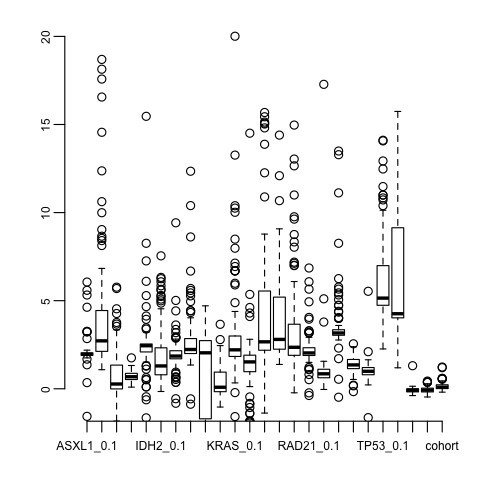

```r
boxplot(t(fitBoots), ylim=c(-1,20))
points(fitBoot$coefficiencts, pch="*", col='red')
```

Concordance on out of bag samples

```r
concBoots <- sapply(1:100, function(foo){
            set.seed(foo)
            w <- which(control)
            s <- sample(seq_along(which(control)), replace=TRUE)
            b <- c(sample(which(control)[s], size=round(n_total) - sum(!control), prob=p[s], replace=TRUE), sample(which(!control), replace=TRUE))
            oob <- !1:nrow(allX) %in% b
            oos <- c(sample(which(oob & control), size=round(n_total) - sum(!control), replace=TRUE), sample(which(oob&!control), size=sum(!control), replace=TRUE))
            c(inb=as.numeric(survConcordance(allSurv[b,]~ as.matrix(allX)[b,] %*% fitBoots[,foo])$concordance),
                    oob=as.numeric(survConcordance(allSurv[oob,]~ as.matrix(allX)[oob,] %*% fitBoots[,foo])$concordance),
                    oos=as.numeric(survConcordance(allSurv[oos,]~ as.matrix(allX)[oos,] %*% fitBoots[,foo])$concordance)
            )
        })
```

```r
looAllWeighted <- do.call("rbind",mclapply(levels(samples), function(l){
                    i <- samples!=l
                    f <<- CoxRFX(allX[i,], allSurv[i,], allGroups, which.mu=which.mu, sigma0=sigma0, nu=nu, weights=weights[i])
                    p <- as.matrix(allX[!i,,drop=FALSE]) %*% f$coefficients
                    r <- cbind(matrix(f$coefficients, nrow=length(p), ncol=length(f$coefficients), byrow=TRUE), linear.predictor=p)
                    colnames(r) <- c(names(f$coefficients), "linear.predictor")
                    as.data.frame(r)
                }, mc.cores=4))
looAllWeighted <- looAllWeighted[order(order(samples)),]
pp <- looAllWeighted$linear.predictor
survConcordance(allSurv ~ pp, weights=weights)
```

```
## Call:
## survConcordance(formula = allSurv ~ pp, weights = weights)
##
##   n= 950
## Concordance= 0.7561883 se= 0.02802535
## concordant discordant  tied.risk  tied.time   std(c-d)
##  6137610.4  1978900.7        0.0        1.0   454936.2
```

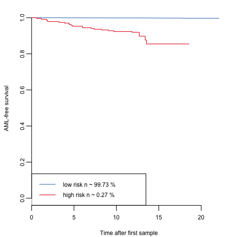

```r
h <- exp(looAllWeighted$linear.predictor) > 100
plot(survfit(allSurv ~ h, weights=weights), col=set1[2:1], ylab="AML-free survival", xlab="Time after first sample")
f <- sum(h*weights)/sum(weights) *100
legend("bottomleft", lty=1, col=set1[2:1], paste(c("low risk", "high risk"), "n ~", round(c( 100-f,f), 2),"%"))
```

### 7.4.9 Individual Predictions with corrected baseline

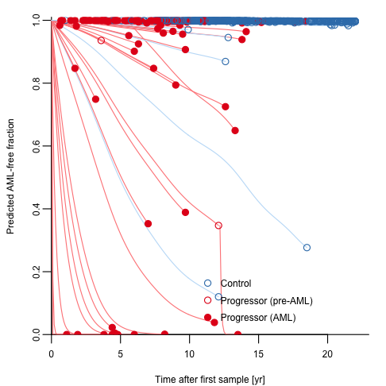

```r
plot(survfit(allSurv~1), conf.int=FALSE, xlab='Time after first sample [yr]', ylab='Predicted AML-free fraction', col='white', bty='L', yaxs='i', ylim=c(0,1.01))
d <- data.frame(t=NULL, s=NULL, pch=NULL, col=character())
for(i in unique(samples)){
    km <- exp(predict(smooth.spline(log(summary(survfit(allSurv[samples!=i,]~1, weights=weights[samples!=i]), times=t)$surv), df=10))$y)
    l0 <- colSums(fitAll$Z[samples!=i,,drop=FALSE] * weights[samples!=i]) %*% as.numeric(looAllWeighted[samples==i,][1,colnames(fitAll$Z)]) / sum(weights[samples!=i])
    kmi <- function(km, s, lp, l0){
        .kmi <- function(km, sj, lpj, l0) km[t >= sj[,1] & t <= sj[,2]]^exp(lpj-l0)
        k0 <- 1
        for(j in 1:nrow(s)) {
            k <- .kmi(km, s[j,], lp[j], l0)
            k <- k * k0/k[1]
            w <- t >= s[j,1] & t <= s[j,2]
            k0 <- k[length(k)]
            c <- if(s[nrow(s),3]==1) set1[1] else set1[2]
            lines(t[w], k, col=mg14:::colTrans(c), type='l')
            p <- if(s[j,3]==1) 19 else 1
            d <<- rbind(d, data.frame(t=t[w][length(k)], s=k[length(k)], pch=p, col=c))
        }
    }
    kmi(km, allSurv[samples==i,], looAllWeighted$linear.predictor[samples==i], l0)
}
points(d$t, d$s, pch=d$pch, col=as.character(d$col))
legend("bottomright", pch=c(1,1,19), col=c(set1[2], set1[1], set1[1]), legend=c("Control", "Progressor (pre-AML)", "Progressor (AML)"), bty='n')
```

Callibration

```r
p10 <- km[t==10]^exp(looAllWeighted$linear.predictor)
c <- cut(p10, c(0,0.4,0.95,0.99,1))
table(c)
```

```
## c
##     (0,0.4]  (0.4,0.95] (0.95,0.99]    (0.99,1]
##          11          16          12         908
```

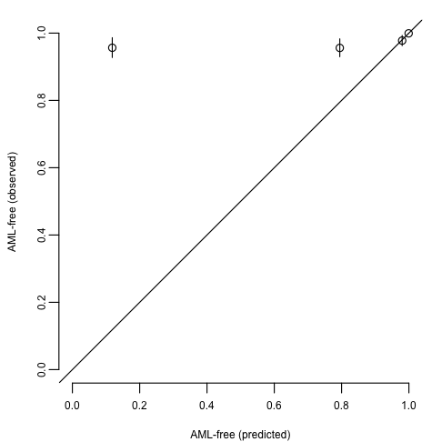

```r
s <- summary(survfit(allSurv~c, weights=weights), times=10)
m <- sapply(split(p10,c), mean)
plot(m, s$surv, xlab="AML-free (predicted)", ylab="AML-free (observed)", xlim=c(0,1), ylim=c(0,1))
segments(m,s$lower,m,s$upper)
abline(0,1)
```

Hazard

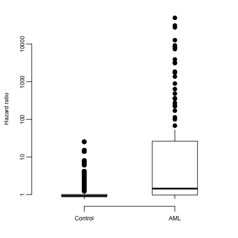

```r
boxplot(exp(fitBoot$linear.predictors) ~ factor(1-control[b42], labels=c("Control","AML")), log='y', ylab="Hazard ratio", pch=19, staplewex=0, lty=1, boxwex=0.5)
```

### 7.4.10 Some simulations

```r
bX <- sapply(1:50, function(foo){
            set.seed(foo)
            X <- rbind(apply(allX[control,], 2, sample, n_total-sum(!control), replace=TRUE), apply(allX[!control,], 2, sample) )
            lambda0 <- 5e-4
            r <- X%*%coef(fitBoot)
            t <- rexp(n_total, lambda0 * exp(r))
            tmax <- 13 + runif(n_total, 0,1)
            s <- Surv(pmin(t,tmax), t < tmax)
            cases <- which(s[,2]==1)
            controls1 <- sample(which(s[,2]==0), size=1*length(cases))
            controls4 <- sample(which(s[,2]==0), size=sum(control))
            cbind(controls_inc=colMeans(X[controls4,allGroups=="Genes"]>0), AML_inc=colMeans(X[cases,allGroups=="Genes"]>0), controls_vaf=apply(X[controls4,allGroups=="Genes"], 2, function(x) mean(x[x>0])),AML_vaf=apply(X[cases,allGroups=="Genes"], 2, function(x) mean(x[x>0])))
        }, simplify='array')
```

Expected vs observed driver frequency

```r
graphics.off()
png("./figures/driver.freq.simulation.png", width = 15, height = 14, units = "cm", res = 500)
par(mar = c(5, 4, 1.5, 0.5) + 0.1, mgp=c(2,0.4,0), las=1, tcl=-0.2, cex = 1)
plot(-rowMeans(bX[,'controls_inc',]), type='h', lend = 2, ylim=c(-.5,1)/2.5, lwd=8, xaxt='n', yaxt = 'n',  ylab="Driver frequency (%)", xlab="", col=pal1[2])
atx <- axTicks(2)
axis(2,at=atx,labels= c(20, 10, 0, 10, 20, 30, 40))
points(x=1:22+.5,-colMeans(allX[control,allGroups=="Genes"]>0), type='h', lend = 2, lwd=8, col=pal1[1])
points(rowMeans(bX[,"AML_inc",]), type='h', lend = 2, lwd=8, col=pal1[2])
points(x=1:22+.5,colMeans(allX[!control,allGroups=="Genes"]>0), type='h', lend = 2, lwd=8, col=pal1[1])
mtext(side=1, at=1:22,sub("_.+","",colnames(allX)[allGroups=="Genes"]), las=2, font=3, line=0.7)
mtext(text = "Pre-AML", side=3, at = 12, las=1, font=1, line=-1.5, cex = 1.1)
mtext(text = "Controls", side=1, at = 12, las=1, font=1, line=-1.5, cex = 1.1)
legend("bottomright", fill=pal1[2:1], c("Expected","Observed"), cex = 0.8)
abline(h=0)
dev.off()
```

Expected vs observed driver VAF

```r
avgVaf <- function(x) mean(x[x>0])

png("./figures/driver.vaf.simulation.png", width = 15, height = 14, units = "cm", res = 500)
par(mar = c(5, 4, 1.5, 0.5) + 0.1, mgp=c(2,0.4,0), las=1, tcl=-0.2, cex=1)
plot(-apply(bX[,'controls_vaf',],1,avgVaf)*10, type='h', lend = 2, ylim=c(-40,50), lwd=8, xaxt='n', yaxt = 'n', ylab="Driver VAF (%)", xlab="", col=pal1[2])
atx <- axTicks(2)
axis(2,at=atx,labels= c(40, 20,0, 20, 40))
points(x=1:22+.5,-apply(allX[control,allGroups=="Genes"],2,avgVaf)*10, type='h', lend = 2, lwd=8, col=pal1[1])
points(apply(bX[,"AML_vaf",],1,avgVaf)*10, type='h', lend = 2, lwd=8, col=pal1[2])
points(x=1:22+.5,apply(allX[!control,allGroups=="Genes"],2,avgVaf)*10, type='h', lend = 2, lwd=8, col=pal1[1])
mtext(side=1, at=1:22,sub("_.+","",colnames(allX)[allGroups=="Genes"]), las=2, font=3, line = 0.7)
mtext(text = "Pre-AML", side=3, at = 12, las=1, font=1, line=-1.5, cex = 1.1)
mtext(text = "Controls", side=1, at = 12, las=1, font=1, line=-1.5, cex = 1.1)
legend("bottomright", fill=pal1[2:1], c("Expected","Observed"), cex = 0.8)
abline(h=0)
dev.off()
```

### 7.4.11 Simple models

```r
samples <- factor(c(as.character(sangerData$Individual), as.character(torontoData$Sample)))
```

max vaf:

```r
v <- apply(allX[,allGroups=="Genes"], 1, max)*10
```

cumulative vaf

```r
c <- apply(allX[,allGroups=="Genes"], 1, sum)*10
```

number of mutations

```r
m <- rowSums(allX[,allGroups=="Genes"]>0)
```

any mutation

```r
a <- as.integer(m>0)
```

#### 7.4.11.1 Presence of any mutation

```r
d <- data.frame(a)
summary(f <- coxph(allSurv ~ ., data=d ))
```

```
## Call:
## coxph(formula = allSurv ~ ., data = d)
##
##   n= 950, number of events= 120
##
##     coef exp(coef) se(coef)     z Pr(>|z|)
## a 1.5144    4.5468   0.2046 7.402 1.35e-13 ***
## ---
## Signif. codes:  0 '***' 0.001 '**' 0.01 '*' 0.05 '.' 0.1 ' ' 1
##
##   exp(coef) exp(-coef) lower .95 upper .95
## a     4.547     0.2199     3.045      6.79
##
## Concordance= 0.672  (se = 0.023 )
## Rsquare= 0.064   (max possible= 0.801 )
## Likelihood ratio test= 63.31  on 1 df,   p=2e-15
## Wald test            = 54.78  on 1 df,   p=1e-13
## Score (logrank) test = 66.02  on 1 df,   p=4e-16
```

```r
los <- do.call("rbind",mclapply(levels(samples), function(l){
  i <- samples!=l
  f <<- coxph(allSurv ~ ., data=d, subset=i)
  p <- as.matrix(d[!i,]) %*% f$coefficients
  r <- cbind(matrix(f$coefficients, nrow=length(p), ncol=length(f$coefficients), byrow=TRUE), linear.predictor=p)
  colnames(r) <- c(names(f$coefficients), "linear.predictor")
  as.data.frame(r)
}, mc.cores=4))
psAnyMt <- los[order(order(samples)),]

survConcordance(allSurv ~ psAnyMt$linear.predictor)
```

```
## Call:
## survConcordance(formula = allSurv ~ psAnyMt$linear.predictor)
##
##   n= 950
## Concordance= 0.5431925 se= 0.02388586
## concordant discordant  tied.risk  tied.time   std(c-d)
##  34829.000  28205.000  13646.000      1.000   3663.136
```

Dynamic/cumulative AUC

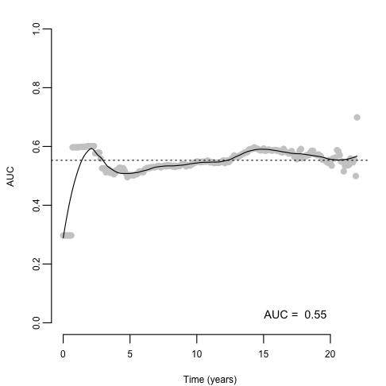

```r
w <- c(which(allSurv[,1]==0)[-1]-1, nrow(allSurv))
survAll2 <- Surv(allSurv[w,2], allSurv[w,3])
t <- seq(0,22,0.1)
allX2 <- allX[w, ]

auc.uno <- AUC.uno(survAll2, survAll2, psAnyMt$linear.predictor[w], times=t)

plot(auc.uno$times, auc.uno$auc, xlab="Time (years)", ylab="AUC", pch=16, col="grey80", ylim = c(0,1.0))
lines(auc.uno$times, predict(loess(auc.uno$auc ~ auc.uno$times, span=0.25)))
abline(h=auc.uno$iauc, lty = 3, lwd = 1)
legend("bottomright", bty = "n", cex = 1.2, legend = paste("AUC = ",round(auc.uno$iauc,2)))
```

```r
AnyMt.a <- auc.uno
```

Presence of any mutation + vaf

```r
d <- data.frame(a,v)
summary(f <- coxph(allSurv ~ ., data=d ))
```

[output not shown]

```r
los <- do.call("rbind",mclapply(levels(samples), function(l){
  i <- samples!=l
  f <<- coxph(allSurv ~ ., data=d, subset=i)
  p <- as.matrix(d[!i,]) %*% f$coefficients
  r <- cbind(matrix(f$coefficients, nrow=length(p), ncol=length(f$coefficients), byrow=TRUE), linear.predictor=p)
  colnames(r) <- c(names(f$coefficients), "linear.predictor")
  as.data.frame(r)
}, mc.cores=4))
psAnyMtVaf <- los[order(order(samples)),]

survConcordance(allSurv ~ psAnyMtVaf$linear.predictor)
```

```
## Call:
## survConcordance(formula = allSurv ~ psAnyMtVaf$linear.predictor)
##
##   n= 950
## Concordance= 0.7287559 se= 0.0238873
## concordant discordant  tied.risk  tied.time   std(c-d)
##  49091.000  14009.000  13580.000      1.000   3663.356
```

Dynamic/cumulative AUC

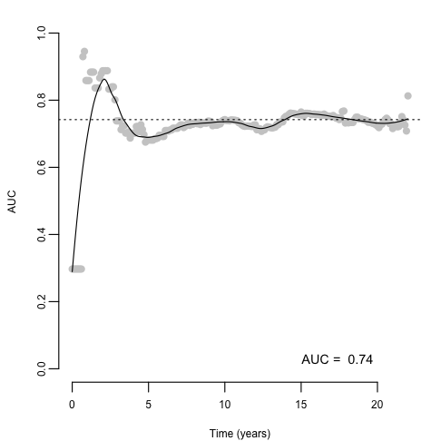

```r
auc.uno <- AUC.uno(survAll2, survAll2, psAnyMtVaf$linear.predictor[w], times=t)

plot(auc.uno$times, auc.uno$auc, xlab="Time (years)", ylab="AUC", pch=16, col="grey80", ylim = c(0,1.0))
lines(auc.uno$times, predict(loess(auc.uno$auc ~ auc.uno$times, span=0.25)))
abline(h=auc.uno$iauc, lty = 3, lwd = 1)
legend("bottomright", bty = "n", cex = 1.2, legend = paste("AUC = ",round(auc.uno$iauc,2)))
```

```r
AnyMtVaf.a <- auc.uno
```

#### 7.4.11.2 Number of mutations + vaf

```r
d <- data.frame(m,v)
summary(f <- coxph(allSurv ~ ., data=d ))
```

[output not shown]

```r
los <- do.call("rbind",mclapply(levels(samples), function(l){
  i <- samples!=l
  f <<- coxph(allSurv ~ ., data=d, subset=i)
  p <- as.matrix(d[!i,]) %*% f$coefficients
  r <- cbind(matrix(f$coefficients, nrow=length(p), ncol=length(f$coefficients), byrow=TRUE), linear.predictor=p)
  colnames(r) <- c(names(f$coefficients), "linear.predictor")
  as.data.frame(r)
}, mc.cores=4))
psNMtVaf <- los[order(order(samples)),]

survConcordance(allSurv ~ psNMtVaf$linear.predictor)
```

```
## Call:
## survConcordance(formula = allSurv ~ psNMtVaf$linear.predictor)
##
##   n= 950
## Concordance= 0.7431403 se= 0.0238873
## concordant discordant  tied.risk  tied.time   std(c-d)
##  50194.000  12906.000  13580.000      1.000   3663.356
```

Dynamic/cumulative AUC

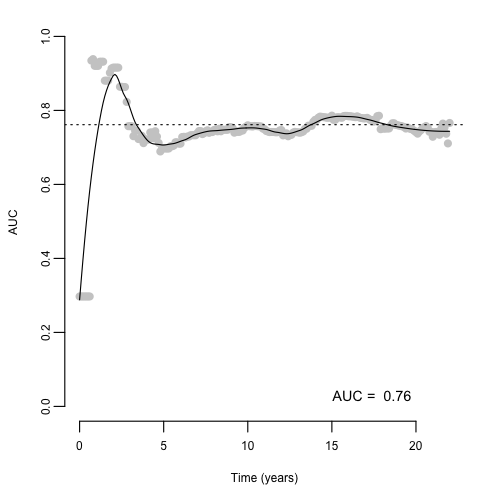

```r
auc.uno <- AUC.uno(survAll2, survAll2, psNMtVaf$linear.predictor[w], times=t)

plot(auc.uno$times, auc.uno$auc, xlab="Time (years)", ylab="AUC", pch=16, col="grey80", ylim = c(0,1.0))
lines(auc.uno$times, predict(loess(auc.uno$auc ~ auc.uno$times, span=0.25)))
abline(h=auc.uno$iauc, lty = 3, lwd = 1)
legend("bottomright", bty = "n", cex = 1.2, legend = paste("AUC = ",round(auc.uno$iauc,2)))
```

```r
NMtVaf.a <- auc.uno
```

#### 7.4.11.3 Number of mutations + cumulative vaf

```r
d <- data.frame(m,c)
summary(f <- coxph(allSurv ~ ., data=d ))
```

```
## Call:
## coxph(formula = allSurv ~ ., data = d)
##
##   n= 950, number of events= 120
##
##       coef exp(coef) se(coef)     z Pr(>|z|)
## m 0.613264  1.846449 0.090393 6.784 1.17e-11 ***
## c 0.033648  1.034220 0.005036 6.681 2.38e-11 ***
## ---
## Signif. codes:  0 '***' 0.001 '**' 0.01 '*' 0.05 '.' 0.1 ' ' 1
##
##   exp(coef) exp(-coef) lower .95 upper .95
## m     1.846     0.5416     1.547     2.204
## c     1.034     0.9669     1.024     1.044
##
## Concordance= 0.744  (se = 0.024 )
## Rsquare= 0.144   (max possible= 0.801 )
## Likelihood ratio test= 148.2  on 2 df,   p=<2e-16
## Wald test            = 223.3  on 2 df,   p=<2e-16
## Score (logrank) test = 350.7  on 2 df,   p=<2e-16
```

```r
los <- do.call("rbind",mclapply(levels(samples), function(l){
  i <- samples!=l
  f <<- coxph(allSurv ~ ., data=d, subset=i)
  p <- as.matrix(d[!i,]) %*% f$coefficients
  r <- cbind(matrix(f$coefficients, nrow=length(p), ncol=length(f$coefficients), byrow=TRUE), linear.predictor=p)
  colnames(r) <- c(names(f$coefficients), "linear.predictor")
  as.data.frame(r)
}, mc.cores=4))
psNMtCumVaf <- los[order(order(samples)),]

survConcordance(allSurv ~ psNMtCumVaf$linear.predictor)
```

```
## Call:
## survConcordance(formula = allSurv ~ psNMtCumVaf$linear.predictor)
##
##   n= 950
## Concordance= 0.743362 se= 0.0238873
## concordant discordant  tied.risk  tied.time   std(c-d)
##  50211.000  12889.000  13580.000      1.000   3663.356
```

Dynamic/cumulative AUC

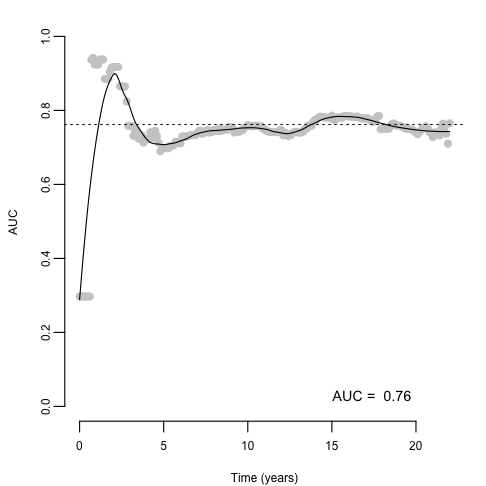

```r
auc.uno <- AUC.uno(survAll2, survAll2, psNMtCumVaf$linear.predictor[w], times=t)

plot(auc.uno$times, auc.uno$auc, xlab="Time (years)", ylab="AUC", pch=16, col="grey80", ylim = c(0,1.0))
lines(auc.uno$times, predict(loess(auc.uno$auc ~ auc.uno$times, span=0.25)))
abline(h=auc.uno$iauc, lty = 3, lwd = 1)
legend("bottomright", bty = "n", cex = 1.2, legend = paste("AUC = ",round(auc.uno$iauc,2)))
```

```r
NMtCumVaf.a <- auc.uno
```

Gene-level risks

```r
d <- allX
summary(f <- coxph(allSurv ~ ., data=d))
```

```
## Call:
## coxph(formula = allSurv ~ ., data = d)
##
##   n= 950, number of events= 120
##
##                  coef  exp(coef)   se(coef)      z Pr(>|z|)
## ASXL1_0.1     0.45410    1.57475    0.25483  1.782   0.0748 .
## BCOR_0.1      4.53517   93.23942   15.29850  0.296   0.7669
## CBL_0.1       0.02418    1.02448    0.74288  0.033   0.9740
## DNMT3A_0.1    0.13468    1.14417    0.18286  0.737   0.4614
## IDH1_0.1      0.39412    1.48307    0.63231  0.623   0.5331
## IDH2_0.1      0.51163    1.66800    0.29079  1.759   0.0785 .
## JAK2_0.1      0.59064    1.80514    0.39331  1.502   0.1332
## KDM6A_0.1     0.15988    1.17337   32.12704  0.005   0.9960
## KMT2C_0.1    -0.50258    0.60497    1.77003 -0.284   0.7765
## KMT2D_0.1    -0.01333    0.98676    0.58364 -0.023   0.9818
## KRAS_0.1      0.54336    1.72178   12.36468  0.044   0.9649
## NF1_0.1      -0.76668    0.46455    5.94275 -0.129   0.8973
## NRAS_0.1      7.40428 1643.00852    6.01855  1.230   0.2186
## PHF6_0.1      4.31340   74.69375   15.42773  0.280   0.7798
## PTPN11_0.1    4.49429   89.50474    6.18432  0.727   0.4674
## RAD21_0.1     0.07319    1.07594    6.89358  0.011   0.9915
## RUNX1_0.1     0.17980    1.19698    0.24611  0.731   0.4650
## SF3B1_0.1     1.10331    3.01414    0.52063  2.119   0.0341 *
## SRSF2_0.1     0.34535    1.41248    0.21771  1.586   0.1127
## TET2_0.1      0.17179    1.18743    0.20206  0.850   0.3952
## TP53_0.1      2.17381    8.79176    0.55321  3.929 8.51e-05 ***
## U2AF1_0.1     2.74012   15.48884    0.35246  7.774 7.58e-15 ***
## age_10       -0.01189    0.98818    0.10907 -0.109   0.9132
## gender       -0.01138    0.98868    0.19862 -0.057   0.9543
## cohort       -0.13561    0.87318    0.23791 -0.570   0.5687
## ---
## Signif. codes:  0 '***' 0.001 '**' 0.01 '*' 0.05 '.' 0.1 ' ' 1
##
##            exp(coef) exp(-coef) lower .95 upper .95
## ASXL1_0.1     1.5747  0.6350222 9.557e-01 2.595e+00
## BCOR_0.1     93.2394  0.0107251 8.861e-12 9.811e+14
## CBL_0.1       1.0245  0.9761095 2.389e-01 4.394e+00
## DNMT3A_0.1    1.1442  0.8739972 7.995e-01 1.637e+00
## IDH1_0.1      1.4831  0.6742750 4.295e-01 5.121e+00
```

[output cut: 11 more lines]

```
## RUNX1_0.1     1.1970  0.8354364 7.389e-01 1.939e+00
## SF3B1_0.1     3.0141  0.3317696 1.086e+00 8.362e+00
## SRSF2_0.1     1.4125  0.7079756 9.219e-01 2.164e+00
## TET2_0.1      1.1874  0.8421566 7.991e-01 1.764e+00
## TP53_0.1      8.7918  0.1137429 2.973e+00 2.600e+01
## U2AF1_0.1    15.4888  0.0645626 7.763e+00 3.091e+01
## age_10        0.9882  1.0119578 7.980e-01 1.224e+00
## gender        0.9887  1.0114489 6.699e-01 1.459e+00
## cohort        0.8732  1.1452345 5.478e-01 1.392e+00
##
## Concordance= 0.81  (se = 0.027 )
## Rsquare= 0.069   (max possible= 0.801 )
## Likelihood ratio test= 67.53  on 25 df,   p=9e-06
## Wald test            = 110.8  on 25 df,   p=9e-13
## Score (logrank) test = 782.6  on 25 df,   p=<2e-16
```